# Data Wrangling and Analysis: WeRateDogs ([@dog_rates](https://twitter.com/dog_rates))

> *By Ambar Canonicco*

> Welcome to this academic project meant to develop and demonstrate my skills on wrangling and cleaning data using Python code to further perform proper analysis.
- Introduction
- Gathering Data
- Assessing Data
- Cleaning Data
- Analyzing Data
- Insights
- Conclusion
- Findings Report
- Data Repository

### Introduction

Real-world data rarely comes clean. Using Python and its libraries, I will gather data from a variety of sources and in a variety of formats, assess its quality and tidiness, then clean it. This is called data wrangling. I will document my wrangling efforts in this Jupyter Notebook, plus showcase them through analyses and visualizations using Python (and its libraries, you'll see).

The dataset that I will be wrangling (and analyzing and visualizing) is the tweet archive of Twitter user @dog_rates, also known as WeRateDogs. WeRateDogs is a Twitter account that rates people's dogs with a humorous comment about the dog. These ratings almost always have a denominator of 10. The numerators, though? Almost always greater than 10. 11/10, 12/10, 13/10, etc. Why? `◖ᵔᴥᵔ◗` Because "they're good dogs Brent." [`# knowyourmeme`](https://knowyourmeme.com/memes/theyre-good-dogs-brent)

> WeRateDogs has over 8 million followers and has received international media coverage.

After performing the wrangling phase of the project, I will decide which questions I think could be answered from the final clean data recollected with my efforts and share the insighful findings with you.

Be ready!

```python
# Import all necesary (or possible) libraries
import pandas as pd # DataFrames
import numpy as np # Number arrays
import matplotlib.pyplot as plt # Fancy Plots
import seaborn as sns # Fancier Plots
import requests as rqs # "HTTP library for Python, built with ♥"}
import json # encoder "easy for humans to read and write"
from IPython.display import display as dpl # print distant cousin
from IPython.display import Image as img # jupyter scrapbook
from IPython.display import HTML # More display libraries
import matplotlib.dates as mdates # More plot libraries
import time # tick tock
from datetime import datetime # Time passess
import tweepy # Access Twitter API for dummies
import re # regex library
%matplotlib inline
```

```python
# Time at the beginning of the code to track elapsed time
notebk_time = time.time()
```

```python
# Define some functions to show all columns and/or rows when a dataframe is displayed
def full(x):
    pd.set_option('display.max_columns', None)
    pd.set_option('display.max_rows', None)
    dpl(x)
    pd.reset_option('display.max_columns')
    pd.reset_option('display.max_rows')

def fullcols(x):
    pd.set_option('display.max_columns', None)
    dpl(x)
    pd.reset_option('display.max_columns')
```

### Gathering Data

To start this project I will gather all the files collected and import it into the notebook so I can work with the data.

I will programmatically download a tweet image prediction file with a URL that I received. The results: a table full of image predictions (the top three only) alongside each tweet ID, image URL, and the image number that corresponded to the most confident prediction (numbered 1 to 4 since tweets can have up to four images).

```python
# Store available data paths
# WeRateDogs twitter archive
d_1 = './data/twitter-archive-enhanced.csv'
# Tweet image prediction file and where I am going to store it
d2_url = 'https://d17h27t6h515a5.cloudfront.net/topher/2017/August/599fd2ad_image-predictions/image-predictions.tsv'
d_2 = './data/image-predictions.tsv'
# Where I am going to store the Twitter API collected data
d_3 = './data/tweet_json.txt'
```

```python
# request Tweet image prediction file
r = rqs.get(d2_url)
# store the file in the path
open(d_2, 'wb').write(r.content);
```

```python
# Read data_1 and data_2 into working variables
df1_raw = pd.read_csv(d_1, sep = ',')
df2_raw = pd.read_csv(d_2, sep = '\t')
```

```python
# Preview data_1 to confirm that it was properly read
df1_raw.head(2)
```

|  | tweet_id | in_reply_to_status_id | in_reply_to_user_id | timestamp | source | text | retweeted_status_id | retweeted_status_user_id | retweeted_status_timestamp | expanded_urls | rating_numerator | rating_denominator | name | doggo | floofer | pupper | puppo |
| --- | --- | --- | --- | --- | --- | --- | --- | --- | --- | --- | --- | --- | --- | --- | --- | --- | --- |
| 0 | 892420643555336193 | nan | nan | 2017-08-01 16:23:56 +0000 | <a href="http://twitter.com/download/iphone" r... | This is Phineas. He's a mystical boy. Only eve... | nan | nan | NaN | https://twitter.com/dog_rates/status/892420643... | 13 | 10 | Phineas | None | None | None | None |
| 1 | 892177421306343426 | nan | nan | 2017-08-01 00:17:27 +0000 | <a href="http://twitter.com/download/iphone" r... | This is Tilly. She's just checking pup on you.... | nan | nan | NaN | https://twitter.com/dog_rates/status/892177421... | 13 | 10 | Tilly | None | None | None | None |

```python
# Preview data_2 to confirm that it was properly read
df2_raw.head(2)
```

|  | tweet_id | jpg_url | img_num | p1 | p1_conf | p1_dog | p2 | p2_conf | p2_dog | p3 | p3_conf | p3_dog |
| --- | --- | --- | --- | --- | --- | --- | --- | --- | --- | --- | --- | --- |
| 0 | 666020888022790149 | https://pbs.twimg.com/media/CT4udn0WwAA0aMy.jpg | 1 | Welsh_springer_spaniel | 0.47 | True | collie | 0.16 | True | Shetland_sheepdog | 0.06 | True |
| 1 | 666029285002620928 | https://pbs.twimg.com/media/CT42GRgUYAA5iDo.jpg | 1 | redbone | 0.51 | True | miniature_pinscher | 0.07 | True | Rhodesian_ridgeback | 0.07 | True |

```python
# DO NOT RUN THIS CELL, PLEASE RUN THE ABOVE AND THEN THE BELOW CELLS. Unless you have half an hour to spend ( ͡° ͜ʖ ͡°)

# Twitter API
# keys and secrets are stored in creds.py
import creds
# Query Twitter API for each tweet in the Twitter archive and save JSON in a text file

auth = tweepy.OAuthHandler(creds.consumer_key, creds.consumer_secret)
auth.set_access_token(creds.access_token, creds.access_secret)

api = tweepy.API(auth, wait_on_rate_limit=True)

# Tweet IDs for which to gather additional data via Twitter's API
tweet_ids = df1_raw.tweet_id.values
len(tweet_ids)

# Query Twitter's API for JSON data for each tweet ID in the Twitter archive
count = 0
fails_dict = {}
start = time.time()

# Save each tweet's returned JSON as a new line in a .txt file and prints the log in another
with open('./data/tweet_json.txt', 'w') as outfile:
    with open('./data/twitter-query-log.txt', 'a+') as api_log:
        # This loop will likely take 20-30 minutes to run because of Twitter's rate limit
        for tweet_id in tweet_ids:
            count += 1
            try:
                tweet = api.get_status(tweet_id, tweet_mode='extended')
                api_log.write(str(count) + ": " + str(tweet_id) + " - Success\n")
                json.dump(tweet._json, outfile)
                outfile.write('\n')
            except tweepy.TweepError as e:
                api_log.write(str(count) + ": " + str(tweet_id) + " - Fail\n")
                fails_dict[tweet_id] = e
                pass
print(round((time.time() - start)/60,1),' minutes')
print(fails_dict)
```

[output not shown]

```python
# Read data into working variables
with open(d_3) as f_in :
    df3_raw = pd.read_json(f_in, lines=True)
```

```python
# Preview data_3 to confirm that it was properly read
fullcols(df3_raw.head(2))
```

|  | contributors | coordinates | created_at | display_text_range | entities | extended_entities | favorite_count | favorited | full_text | geo | id | id_str | in_reply_to_screen_name | in_reply_to_status_id | in_reply_to_status_id_str | in_reply_to_user_id | in_reply_to_user_id_str | is_quote_status | lang | place | possibly_sensitive | possibly_sensitive_appealable | quoted_status | quoted_status_id | quoted_status_id_str | quoted_status_permalink | retweet_count | retweeted | retweeted_status | … |
| --- | --- | --- | --- | --- | --- | --- | --- | --- | --- | --- | --- | --- | --- | --- | --- | --- | --- | --- | --- | --- | --- | --- | --- | --- | --- | --- | --- | --- | --- | --- |
| 0 | nan | nan | 2017-08-01 16:23:56 | [0, 85] | {'hashtags': [], 'symbols': [], 'user_mentions... | {'media': [{'id': 892420639486877696, 'id_str'... | 36309 | False | This is Phineas. He's a mystical boy. Only eve... | nan | 892420643555336193 | 892420643555336192 | None | nan | nan | nan | nan | False | en | None | 0.00 | 0.00 | NaN | nan | nan | NaN | 7729 | False | NaN | … |
| 1 | nan | nan | 2017-08-01 00:17:27 | [0, 138] | {'hashtags': [], 'symbols': [], 'user_mentions... | {'media': [{'id': 892177413194625024, 'id_str'... | 31298 | False | This is Tilly. She's just checking pup on you.... | nan | 892177421306343426 | 892177421306343424 | None | nan | nan | nan | nan | False | en | None | 0.00 | 0.00 | NaN | nan | nan | NaN | 5720 | False | NaN | … |

### Assessing Data

During this phase I am going to take a closer look at the data to assess quality of the data, which can be expanded into four main dimensions:

|  | Completeness | Validity | Accuracy | Consistency |
| --- | --- | --- | --- | --- |
| **Issues** | Missing data | Data that makes no sense for the observation | Even though it could be valid and make sense, data that is not true or do not belong to the observation | The data may be correct but is not formatted in the same way, is not standarized across de dataset |

On the other hand, we can encounter with tidy data, which is more reffered to messy and not-user-friendly data. The information may be complete, valid, accurate and consistent, but it is not readable, cannot be analised an/or cannot be matched with other datasets. Meaning, in general, issues with data structure or semantics. We learned that *Each variable must have its own column, each observation must have its own row, and each type of observational unit should be stored in its own table.*

> *I was requested to identify and clean at least 8 quality issues and at least 2 tidiness issues in this dataset. I performed this assessment using the following code cells. However, you can read my notes in this section.*
- Quality issues
  1. Columns `contributors, coordinates, geo, quoted_status, quoted_status_id, quoted_status_id_str, place, quoted_status_permalink` are empty.
  2. Twenty-three tweets are replies.
  3. Dogs names column have 'none' and letters that do not form words.
  4. The `timestamp` column is stored as string.
  5. Also this after the time ends with a '+0000' string.
  6. Dog breed image predictons `p1, p2, p3` contains predictions of items that are not dog breeds.
  7. These predictions have inconsistently in upper, lower or title cases.
  8. Additionally, have underscores for spaces when breeds, or other rare stuff, have more than one word.
  9. Seventy-two tweets are retweets.
  10. Max numerator is 1776.
  11. The tweet_id is stored as int.
  12. In the `rating_denominator` column, though they are usually /10, there are 15 different ratings up to 170.
  13. The `possibly_sensitive` and `possibly_sensitive_appealable` columns are all zeros.
- Tidiness issues
  1. Columns `text` and `full_text` may be the same.
  2. Our three raw datasets belong to the same type of observational unit "a tweet".
  3. There is a variable that we will call `dog_stage` that is spread in 4 columns `doggo, floofer, pupper and puppo`.
  4. The `columns entities` and `extended_entities` has a dictionary within each cell.
  5. `user` column hides very interesting information on the user.
  6. As all of the tweets are from the same user, this information should go in a different table.

These observations above were noted after joining all the data together in the same data frame and may have been completed in different times of the assessing process. Do not be scared if they are not treated sequencially through the code! Although you will not get lost while reading the code `•ᴗ•`

```python
# Read the log file I've created
apilog = pd.read_csv('./data/twitter-query-log.txt','r', header = None)
```

```python
# Parsing the log file
apilog = apilog[0].str.split(':', expand = True)
apilog = apilog[1].str.split('-', expand = True)
apilog.columns = ['id','status']
```

```python
# Count values in log file to check how many fails
apilog.status.value_counts()
```

```
 Success    2331
 Fail         25
Name: status, dtype: int64
```

> *Noted that 25 ids failed during the api activity*

```python
# set tweet id as index for all data
df1_raw = df1_raw.set_index('tweet_id')
df2_raw = df2_raw.set_index('tweet_id')
df3_raw = df3_raw.set_index('id')
dpl(df1_raw.head(1))
dpl(df2_raw.head(1))
dpl(df3_raw.head(1))
```

| tweet_id | in_reply_to_status_id | in_reply_to_user_id | timestamp | source | text | retweeted_status_id | retweeted_status_user_id | retweeted_status_timestamp | expanded_urls | rating_numerator | rating_denominator | name | doggo | floofer | pupper | puppo |
| --- | --- | --- | --- | --- | --- | --- | --- | --- | --- | --- | --- | --- | --- | --- | --- | --- |
| 892420643555336193 | nan | nan | 2017-08-01 16:23:56 +0000 | <a href="http://twitter.com/download/iphone" r... | This is Phineas. He's a mystical boy. Only eve... | nan | nan | NaN | https://twitter.com/dog_rates/status/892420643... | 13 | 10 | Phineas | None | None | None | None |

| tweet_id | jpg_url | img_num | p1 | p1_conf | p1_dog | p2 | p2_conf | p2_dog | p3 | p3_conf | p3_dog |
| --- | --- | --- | --- | --- | --- | --- | --- | --- | --- | --- | --- |
| 666020888022790149 | https://pbs.twimg.com/media/CT4udn0WwAA0aMy.jpg | 1 | Welsh_springer_spaniel | 0.47 | True | collie | 0.16 | True | Shetland_sheepdog | 0.06 | True |

| id | contributors | coordinates | created_at | display_text_range | entities | extended_entities | favorite_count | favorited | full_text | geo | ... | quoted_status | quoted_status_id | quoted_status_id_str | quoted_status_permalink | retweet_count | retweeted | retweeted_status | source | truncated | user |
| --- | --- | --- | --- | --- | --- | --- | --- | --- | --- | --- | --- | --- | --- | --- | --- | --- | --- | --- | --- | --- | --- |
| 892420643555336193 | nan | nan | 2017-08-01 16:23:56 | [0, 85] | {'hashtags': [], 'symbols': [], 'user_mentions... | {'media': [{'id': 892420639486877696, 'id_str'... | 36309 | False | This is Phineas. He's a mystical boy. Only eve... | nan | ... | NaN | nan | nan | NaN | 7729 | False | NaN | <a href="http://twitter.com/download/iphone" r... | False | {'id': 4196983835, 'id_str': '4196983835', 'na... |

1 rows × 31 columns

```python
# Join all sources into one table
df = (df1_raw.join(
    df2_raw, how = 'inner', lsuffix='_1', rsuffix='_2')).join (
    df3_raw, how = 'inner', rsuffix='_3')
fullcols(df)
```

[output not shown]

2059 rows × 58 columns

```python
# Reformat number display to decimal and not scientific
pd.options.display.float_format = '{:.2f}'.format
```

```python
# Check for information on dataframe
full(df.info())
full(df.describe())
```

```
<class 'pandas.core.frame.DataFrame'>
Int64Index: 2059 entries, 892420643555336193 to 666020888022790149
Data columns (total 58 columns):
in_reply_to_status_id            23 non-null float64
in_reply_to_user_id              23 non-null float64
timestamp                        2059 non-null object
source                           2059 non-null object
text                             2059 non-null object
retweeted_status_id              72 non-null float64
retweeted_status_user_id         72 non-null float64
retweeted_status_timestamp       72 non-null object
expanded_urls                    2059 non-null object
rating_numerator                 2059 non-null int64
rating_denominator               2059 non-null int64
name                             2059 non-null object
doggo                            2059 non-null object
floofer                          2059 non-null object
pupper                           2059 non-null object
puppo                            2059 non-null object
jpg_url                          2059 non-null object
img_num                          2059 non-null int64
p1                               2059 non-null object
p1_conf                          2059 non-null float64
p1_dog                           2059 non-null bool
p2                               2059 non-null object
p2_conf                          2059 non-null float64
p2_dog                           2059 non-null bool
p3                               2059 non-null object
p3_conf                          2059 non-null float64
p3_dog                           2059 non-null bool
contributors                     0 non-null float64
coordinates                      0 non-null float64
created_at                       2059 non-null datetime64[ns]
display_text_range               2059 non-null object
entities                         2059 non-null object
extended_entities                2059 non-null object
favorite_count                   2059 non-null int64
favorited                        2059 non-null bool
full_text                        2059 non-null object
geo                              0 non-null float64
```

[output cut: 8 more lines]

```
place                            1 non-null object
possibly_sensitive               2059 non-null float64
possibly_sensitive_appealable    2059 non-null float64
quoted_status                    0 non-null object
quoted_status_id                 0 non-null float64
quoted_status_id_str             0 non-null float64
quoted_status_permalink          0 non-null object
retweet_count                    2059 non-null int64
retweeted                        2059 non-null bool
retweeted_status                 72 non-null object
source_3                         2059 non-null object
truncated                        2059 non-null bool
user                             2059 non-null object
dtypes: bool(7), datetime64[ns](1), float64(18), int64(6), object(26)
memory usage: 850.5+ KB
```

```
None
```

|  | in_reply_to_status_id | in_reply_to_user_id | retweeted_status_id | retweeted_status_user_id | rating_numerator | rating_denominator | img_num | p1_conf | p2_conf | p3_conf | contributors | coordinates | favorite_count | geo | id_str | in_reply_to_status_id_3 | in_reply_to_status_id_str | in_reply_to_user_id_3 | in_reply_to_user_id_str | possibly_sensitive | possibly_sensitive_appealable | quoted_status_id | quoted_status_id_str | retweet_count |
| --- | --- | --- | --- | --- | --- | --- | --- | --- | --- | --- | --- | --- | --- | --- | --- | --- | --- | --- | --- | --- | --- | --- | --- | --- |
| count | 23.00 | 23.00 | 72.00 | 72.00 | 2059.00 | 2059.00 | 2059.00 | 2059.00 | 2059.00 | 2059.00 | 0.00 | 0.00 | 2059.00 | 0.00 | 2059.00 | 23.00 | 23.00 | 23.00 | 23.00 | 2059.00 | 2059.00 | 0.00 | 0.00 | 2059.00 |
| mean | 697811153875140736.00 | 4196983835.00 | 762124596667010944.00 | 10936972768270904.00 | 12.26 | 10.52 | 1.20 | 0.59 | 0.13 | 0.06 | nan | nan | 8008.93 | nan | 737834542426394496.00 | 697811153875140736.00 | 697811153875140736.00 | 4196983835.00 | 4196983835.00 | 0.00 | 0.00 | nan | nan | 2593.96 |
| std | 43593835628401896.00 | 0.00 | 58740997955524048.00 | 92803260143106704.00 | 40.84 | 7.20 | 0.56 | 0.27 | 0.10 | 0.05 | nan | nan | 12095.16 | nan | 67584106893064992.00 | 43593835628401896.00 | 43593835628401896.00 | 0.00 | 0.00 | 0.00 | 0.00 | nan | nan | 4530.97 |
| min | 667152164079423488.00 | 4196983835.00 | 667509364010450944.00 | 783214.00 | 0.00 | 2.00 | 1.00 | 0.04 | 0.00 | 0.00 | nan | nan | 0.00 | nan | 666020888022790144.00 | 667152164079423488.00 | 667152164079423488.00 | 4196983835.00 | 4196983835.00 | 0.00 | 0.00 | nan | nan | 11.00 |
| 25% | 673241069914580992.00 | 4196983835.00 | 710673828503034880.00 | 4196983835.00 | 10.00 | 10.00 | 1.00 | 0.36 | 0.05 | 0.02 | nan | nan | 1524.50 | nan | 676250470523015168.00 | 673241069914580992.00 | 673241069914580992.00 | 4196983835.00 | 4196983835.00 | 0.00 | 0.00 | nan | nan | 555.00 |
| 50% | 675707330206547968.00 | 4196983835.00 | 776898769598197760.00 | 4196983835.00 | 11.00 | 10.00 | 1.00 | 0.59 | 0.12 | 0.05 | nan | nan | 3528.00 | nan | 711306686208872448.00 | 675707330206547968.00 | 675707330206547968.00 | 4196983835.00 | 4196983835.00 | 0.00 | 0.00 | nan | nan | 1228.00 |
| 75% | 703148942731661312.00 | 4196983835.00 | 797147667415614464.00 | 4196983835.00 | 12.00 | 10.00 | 1.00 | 0.84 | 0.20 | 0.09 | nan | nan | 9992.00 | nan | 792898596584728576.00 | 703148942731661312.00 | 703148942731661312.00 | 4196983835.00 | 4196983835.00 | 0.00 | 0.00 | nan | nan | 2984.00 |
| max | 855818117272018944.00 | 4196983835.00 | 876850772322988032.00 | 787461778435289088.00 | 1776.00 | 170.00 | 4.00 | 1.00 | 0.49 | 0.27 | nan | nan | 156724.00 | nan | 892420643555336192.00 | 855818117272018944.00 | 855818117272018944.00 | 4196983835.00 | 4196983835.00 | 0.00 | 0.00 | nan | nan | 78107.00 |

```python
# Confirm if the unique value in this column can be dropped
pd.DataFrame(df['place'].dropna())
```

|  | place |
| --- | --- |
| 763183847194451968 | {'id': '7356b662670b2c31', 'url': 'https://api... |

```python
# Get dog names counts
df['name'].value_counts()
```

```
None          573
a              55
Cooper         10
Charlie        10
Tucker         10
Oliver         10
Penny          10
Lucy            9
Winston         8
Sadie           8
Lola            8
Bo              8
the             7
an              7
Daisy           7
Toby            7
Bailey          6
Milo            6
Scout           6
Rusty           6
Dave            6
Koda            6
Jax             6
Stanley         6
Bella           6
Oscar           5
Louis           5
Alfie           5
Larry           5
Buddy           5
             ...
Florence        1
Tito            1
Stella          1
Bluebert        1
Reptar          1
Brandonald      1
Alexander       1
Kollin          1
Mojo            1
Tater           1
Banditt         1
Ruffles         1
Roscoe          1
Jay             1
Beckham         1
Ashleigh        1
Obi             1
Lenox           1
Maude           1
Jett            1
Rueben          1
Lillie          1
Arlo            1
Fido            1
Ito             1
Mary            1
Cupid           1
Newt            1
Jeb             1
Pupcasso        1
Name: name, Length: 934, dtype: int64
```

```python
# Count how many different denominators there are
len(df['rating_denominator'].value_counts())
```

```
15
```

```python
# Get counts of unique values in predictor columns
dpl(df['p1'].value_counts())
dpl(df['p2'].value_counts())
dpl(df['p3'].value_counts())
```

```
golden_retriever             150
Labrador_retriever            97
Pembroke                      88
Chihuahua                     81
pug                           57
chow                          44
Samoyed                       42
Pomeranian                    38
toy_poodle                    38
cocker_spaniel                30
malamute                      30
French_bulldog                25
Chesapeake_Bay_retriever      23
miniature_pinscher            23
seat_belt                     22
Siberian_husky                20
German_shepherd               20
Cardigan                      19
web_site                      19
Eskimo_dog                    18
Maltese_dog                   18
Staffordshire_bullterrier     18
beagle                        18
Shetland_sheepdog             18
teddy                         18
Rottweiler                    17
Lakeland_terrier              17
Shih-Tzu                      17
Italian_greyhound             16
kuvasz                        16
                            ...
African_grey                   1
conch                          1
guenon                         1
ocarina                        1
remote_control                 1
walking_stick                  1
studio_couch                   1
pool_table                     1
ice_lolly                      1
hammer                         1
giant_panda                    1
carousel                       1
banana                         1
wild_boar                      1
marmot                         1
shield                         1
china_cabinet                  1
cheeseburger                   1
laptop                         1
padlock                        1
pot                            1
quilt                          1
bonnet                         1
electric_fan                   1
school_bus                     1
cougar                         1
teapot                         1
cowboy_boot                    1
dining_table                   1
bookcase                       1
Name: p1, Length: 378, dtype: int64
```

```
Labrador_retriever                104
golden_retriever                   90
Cardigan                           73
Chihuahua                          44
Pomeranian                         41
Chesapeake_Bay_retriever           41
French_bulldog                     40
toy_poodle                         37
cocker_spaniel                     34
Siberian_husky                     33
miniature_poodle                   33
beagle                             28
collie                             27
Pembroke                           27
Eskimo_dog                         27
kuvasz                             26
Italian_greyhound                  22
Pekinese                           21
Samoyed                            20
miniature_pinscher                 20
malinois                           20
chow                               20
American_Staffordshire_terrier     19
Norwegian_elkhound                 19
toy_terrier                        19
Boston_bull                        18
Staffordshire_bullterrier          17
Irish_terrier                      17
pug                                17
Shih-Tzu                           16
                                 ...
junco                               1
nail                                1
bathing_cap                         1
red_fox                             1
platypus                            1
hyena                               1
printer                             1
canoe                               1
sandbar                             1
bannister                           1
crib                                1
chimpanzee                          1
sock                                1
cliff                               1
cloak                               1
coral_fungus                        1
timber_wolf                         1
wood_rabbit                         1
mailbox                             1
cornet                              1
patio                               1
tarantula                           1
Japanese_spaniel                    1
sliding_door                        1
bobsled                             1
home_theater                        1
coral_reef                          1
projectile                          1
Kerry_blue_terrier                  1
boathouse                           1
Name: p2, Length: 403, dtype: int64
```

```
Labrador_retriever                79
Chihuahua                         58
golden_retriever                  48
Eskimo_dog                        38
kelpie                            34
kuvasz                            34
chow                              32
Staffordshire_bullterrier         32
cocker_spaniel                    29
toy_poodle                        29
Pekinese                          29
beagle                            29
Pomeranian                        28
Pembroke                          27
Great_Pyrenees                    27
malamute                          26
French_bulldog                    26
Chesapeake_Bay_retriever          24
American_Staffordshire_terrier    24
Cardigan                          23
pug                               23
basenji                           21
bull_mastiff                      20
toy_terrier                       19
Siberian_husky                    19
Shetland_sheepdog                 17
Boston_bull                       17
Lakeland_terrier                  16
doormat                           16
German_shepherd                   15
                                  ..
African_chameleon                  1
plastic_bag                        1
wallet                             1
grey_fox                           1
shower_cap                         1
balance_beam                       1
lion                               1
nail                               1
soccer_ball                        1
maraca                             1
common_newt                        1
cheetah                            1
mountain_tent                      1
croquet_ball                       1
desktop_computer                   1
moped                              1
chain                              1
whiptail                           1
panpipe                            1
black_swan                         1
viaduct                            1
green_lizard                       1
red_wolf                           1
soap_dispenser                     1
buckeye                            1
loggerhead                         1
cup                                1
marmot                             1
drumstick                          1
coffeepot                          1
Name: p3, Length: 407, dtype: int64
```

### Cleaning Data

During this section I will address the issues found in the assessment phase and clean any more issues that I encounter in my path.

```python
# Getting rid of fully empty columns and place column
df = df.dropna(axis = 1, how = 'all').drop('place', axis=1)
fullcols(df.info())
```

```
<class 'pandas.core.frame.DataFrame'>
Int64Index: 2059 entries, 892420643555336193 to 666020888022790149
Data columns (total 50 columns):
in_reply_to_status_id            23 non-null float64
in_reply_to_user_id              23 non-null float64
timestamp                        2059 non-null object
source                           2059 non-null object
text                             2059 non-null object
retweeted_status_id              72 non-null float64
retweeted_status_user_id         72 non-null float64
retweeted_status_timestamp       72 non-null object
expanded_urls                    2059 non-null object
rating_numerator                 2059 non-null int64
rating_denominator               2059 non-null int64
name                             2059 non-null object
doggo                            2059 non-null object
floofer                          2059 non-null object
pupper                           2059 non-null object
puppo                            2059 non-null object
jpg_url                          2059 non-null object
img_num                          2059 non-null int64
p1                               2059 non-null object
p1_conf                          2059 non-null float64
p1_dog                           2059 non-null bool
p2                               2059 non-null object
p2_conf                          2059 non-null float64
p2_dog                           2059 non-null bool
p3                               2059 non-null object
p3_conf                          2059 non-null float64
p3_dog                           2059 non-null bool
created_at                       2059 non-null datetime64[ns]
display_text_range               2059 non-null object
entities                         2059 non-null object
extended_entities                2059 non-null object
favorite_count                   2059 non-null int64
favorited                        2059 non-null bool
full_text                        2059 non-null object
id_str                           2059 non-null int64
in_reply_to_screen_name          23 non-null object
in_reply_to_status_id_3          23 non-null float64
in_reply_to_status_id_str        23 non-null float64
in_reply_to_user_id_3            23 non-null float64
in_reply_to_user_id_str          23 non-null float64
is_quote_status                  2059 non-null bool
lang                             2059 non-null object
possibly_sensitive               2059 non-null float64
possibly_sensitive_appealable    2059 non-null float64
retweet_count                    2059 non-null int64
retweeted                        2059 non-null bool
retweeted_status                 72 non-null object
source_3                         2059 non-null object
truncated                        2059 non-null bool
user                             2059 non-null object
dtypes: bool(7), datetime64[ns](1), float64(13), int64(6), object(23)
memory usage: 721.9+ KB
```

```
None
```

```python
# Getting rid of replies
df = df[df['in_reply_to_status_id'].notnull() == False]
df.shape
```

```
(2036, 50)
```

```python
# Getting rid of retweets
df = df[df['retweeted_status_id'].notnull() == False]
df.shape
```

```
(1964, 50)
```

```python
# Getting rid of new full empty columns
df = df.dropna(axis = 1, how = 'all')
fullcols(df.info())
```

```
<class 'pandas.core.frame.DataFrame'>
Int64Index: 1964 entries, 892420643555336193 to 666020888022790149
Data columns (total 39 columns):
timestamp                        1964 non-null object
source                           1964 non-null object
text                             1964 non-null object
expanded_urls                    1964 non-null object
rating_numerator                 1964 non-null int64
rating_denominator               1964 non-null int64
name                             1964 non-null object
doggo                            1964 non-null object
floofer                          1964 non-null object
pupper                           1964 non-null object
puppo                            1964 non-null object
jpg_url                          1964 non-null object
img_num                          1964 non-null int64
p1                               1964 non-null object
p1_conf                          1964 non-null float64
p1_dog                           1964 non-null bool
p2                               1964 non-null object
p2_conf                          1964 non-null float64
p2_dog                           1964 non-null bool
p3                               1964 non-null object
p3_conf                          1964 non-null float64
p3_dog                           1964 non-null bool
created_at                       1964 non-null datetime64[ns]
display_text_range               1964 non-null object
entities                         1964 non-null object
extended_entities                1964 non-null object
favorite_count                   1964 non-null int64
favorited                        1964 non-null bool
full_text                        1964 non-null object
id_str                           1964 non-null int64
is_quote_status                  1964 non-null bool
lang                             1964 non-null object
possibly_sensitive               1964 non-null float64
possibly_sensitive_appealable    1964 non-null float64
retweet_count                    1964 non-null int64
retweeted                        1964 non-null bool
source_3                         1964 non-null object
truncated                        1964 non-null bool
user                             1964 non-null object
dtypes: bool(7), datetime64[ns](1), float64(5), int64(6), object(20)
memory usage: 519.8+ KB
```

```
None
```

```python
# Fixing timestamp dtype
df['timestamp'] = df['timestamp'].copy().apply(lambda x: x[0:len(x)-6])
df['timestamp'] = pd.to_datetime(df['timestamp'])
df['timestamp'].head(2)
```

```
892420643555336193   2017-08-01 16:23:56
892177421306343426   2017-08-01 00:17:27
Name: timestamp, dtype: datetime64[ns]
```

```python
# Getting rid of possibly_sensitive and possibly_sensitive_appealable columns
df = df.drop(['possibly_sensitive','possibly_sensitive_appealable'], axis = 1)
df.info()
```

```
<class 'pandas.core.frame.DataFrame'>
Int64Index: 1964 entries, 892420643555336193 to 666020888022790149
Data columns (total 37 columns):
timestamp             1964 non-null datetime64[ns]
source                1964 non-null object
text                  1964 non-null object
expanded_urls         1964 non-null object
rating_numerator      1964 non-null int64
rating_denominator    1964 non-null int64
name                  1964 non-null object
doggo                 1964 non-null object
floofer               1964 non-null object
pupper                1964 non-null object
puppo                 1964 non-null object
jpg_url               1964 non-null object
img_num               1964 non-null int64
p1                    1964 non-null object
p1_conf               1964 non-null float64
p1_dog                1964 non-null bool
p2                    1964 non-null object
p2_conf               1964 non-null float64
p2_dog                1964 non-null bool
p3                    1964 non-null object
p3_conf               1964 non-null float64
p3_dog                1964 non-null bool
created_at            1964 non-null datetime64[ns]
display_text_range    1964 non-null object
entities              1964 non-null object
extended_entities     1964 non-null object
favorite_count        1964 non-null int64
favorited             1964 non-null bool
full_text             1964 non-null object
id_str                1964 non-null int64
is_quote_status       1964 non-null bool
lang                  1964 non-null object
retweet_count         1964 non-null int64
retweeted             1964 non-null bool
source_3              1964 non-null object
truncated             1964 non-null bool
user                  1964 non-null object
dtypes: bool(7), datetime64[ns](2), float64(3), int64(6), object(19)
memory usage: 489.1+ KB
```

```python
# Fixing predictions format
df['p1'] = df['p1'].str.lower().str.replace('_',' ')
df['p2'] = df['p2'].str.lower().str.replace('_',' ')
df['p3'] = df['p3'].str.lower().str.replace('_',' ')
fullcols(df.sample(5))
```

|  | timestamp | source | text | expanded_urls | rating_numerator | rating_denominator | name | doggo | floofer | pupper | puppo | jpg_url | img_num | p1 | p1_conf | p1_dog | p2 | p2_conf | p2_dog | p3 | p3_conf | p3_dog | created_at | display_text_range | entities | extended_entities | favorite_count | favorited | full_text | … |
| --- | --- | --- | --- | --- | --- | --- | --- | --- | --- | --- | --- | --- | --- | --- | --- | --- | --- | --- | --- | --- | --- | --- | --- | --- | --- | --- | --- | --- | --- | --- |
| 711732680602345472 | 2016-03-21 01:54:29 | <a href="http://twitter.com/download/iphone" r... | I want to hear the joke this dog was just told... | https://twitter.com/dog_rates/status/711732680... | 10 | 10 | None | None | None | None | None | https://pbs.twimg.com/media/CeCVGEbUYAASeY4.jpg | 3 | dingo | 0.37 | False | ibizan hound | 0.33 | True | eskimo dog | 0.07 | True | 2016-03-21 01:54:29 | [0, 77] | {'hashtags': [], 'symbols': [], 'user_mentions... | {'media': [{'id': 711732672607821824, 'id_str'... | 8805 | False | I want to hear the joke this dog was just told... | … |
| 690959652130045952 | 2016-01-23 18:09:53 | <a href="http://twitter.com/download/iphone" r... | This golden is happy to refute the soft mouth ... | https://twitter.com/dog_rates/status/690959652... | 11 | 10 | None | None | None | None | None | https://pbs.twimg.com/media/CZbIIM-WkAIPClg.jpg | 2 | golden retriever | 0.86 | True | labrador retriever | 0.04 | True | saluki | 0.01 | True | 2016-01-23 18:09:53 | [0, 139] | {'hashtags': [{'text': 'notallpuppers', 'indic... | {'media': [{'id': 690959636103577600, 'id_str'... | 3577 | False | This golden is happy to refute the soft mouth ... | … |
| 671547767500775424 | 2015-12-01 04:33:59 | <a href="http://twitter.com/download/iphone" r... | This is Marley. She chews shoes then feels ext... | https://twitter.com/dog_rates/status/671547767... | 10 | 10 | Marley | None | None | None | None | https://pbs.twimg.com/media/CVHRIiqWEAAj98K.jpg | 2 | loafer | 0.26 | False | platypus | 0.09 | False | cowboy boot | 0.07 | False | 2015-12-01 04:33:59 | [0, 127] | {'hashtags': [], 'symbols': [], 'user_mentions... | {'media': [{'id': 671547764132704256, 'id_str'... | 1300 | False | This is Marley. She chews shoes then feels ext... | … |
| 676897532954456065 | 2015-12-15 22:52:02 | <a href="http://twitter.com/download/iphone" r... | Exotic handheld dog here. Appears unathletic. ... | https://twitter.com/dog_rates/status/676897532... | 5 | 10 | None | None | None | None | None | https://pbs.twimg.com/media/CWTSt0UW4AALMNB.jpg | 1 | hamster | 0.63 | False | guinea pig | 0.32 | False | macaque | 0.01 | False | 2015-12-15 22:52:02 | [0, 138] | {'hashtags': [], 'symbols': [], 'user_mentions... | {'media': [{'id': 676897528592392192, 'id_str'... | 2216 | False | Exotic handheld dog here. Appears unathletic. ... | … |
| 707420581654872064 | 2016-03-09 04:19:44 | <a href="http://twitter.com/download/iphone" r... | This is Keurig. He's a rare dog. Laughs like a... | https://twitter.com/dog_rates/status/707420581... | 4 | 10 | Keurig | None | None | None | None | https://pbs.twimg.com/media/CdFDQVgWIAArslx.jpg | 1 | ram | 0.52 | False | kuvasz | 0.15 | True | great pyrenees | 0.11 | True | 2016-03-09 04:19:44 | [0, 140] | {'hashtags': [], 'symbols': [], 'user_mentions... | {'media': [{'id': 707420564403658752, 'id_str'... | 2273 | False | This is Keurig. He's a rare dog. Laughs like a... | … |

```python
# Reformat entities column
df.entities.head(1)
```

```
892420643555336193    {'hashtags': [], 'symbols': [], 'user_mentions...
Name: entities, dtype: object
```

```python
# Reformat entities column (cont.)
def fullcell(dataframe,column,index):
    pd.set_option('display.max_colwidth', len(dataframe[column][0:1]))
    dpl(dataframe[column][index])
    pd.reset_option('display.max_colwidth')
```

```python
# Review the contents of one cell in entities
fullcell(df,'entities',892420643555336193)
```

```
{'hashtags': [],
 'symbols': [],
 'user_mentions': [],
 'urls': [],
 'media': [{'id': 892420639486877696,
   'id_str': '892420639486877696',
   'indices': [86, 109],
   'media_url': 'http://pbs.twimg.com/media/DGKD1-bXoAAIAUK.jpg',
   'media_url_https': 'https://pbs.twimg.com/media/DGKD1-bXoAAIAUK.jpg',
   'url': 'https://t.co/MgUWQ76dJU',
   'display_url': 'pic.twitter.com/MgUWQ76dJU',
   'expanded_url': 'https://twitter.com/dog_rates/status/892420643555336193/photo/1',
   'type': 'photo',
   'sizes': {'thumb': {'w': 150, 'h': 150, 'resize': 'crop'},
    'medium': {'w': 540, 'h': 528, 'resize': 'fit'},
    'small': {'w': 540, 'h': 528, 'resize': 'fit'},
    'large': {'w': 540, 'h': 528, 'resize': 'fit'}}}]}
```

```python
# Reformat entities column (cont.)
df[['hashtags', 'symbols', 'user_mentions', 'urls', 'media']] = df.entities.apply(pd.Series)
df = df.drop('entities', axis=1)
fullcols(df.head(3))
```

|  | timestamp | source | text | expanded_urls | rating_numerator | rating_denominator | name | doggo | floofer | pupper | puppo | jpg_url | img_num | p1 | p1_conf | p1_dog | p2 | p2_conf | p2_dog | p3 | p3_conf | p3_dog | created_at | display_text_range | extended_entities | favorite_count | favorited | full_text | id_str | … |
| --- | --- | --- | --- | --- | --- | --- | --- | --- | --- | --- | --- | --- | --- | --- | --- | --- | --- | --- | --- | --- | --- | --- | --- | --- | --- | --- | --- | --- | --- | --- |
| 892420643555336193 | 2017-08-01 16:23:56 | <a href="http://twitter.com/download/iphone" r... | This is Phineas. He's a mystical boy. Only eve... | https://twitter.com/dog_rates/status/892420643... | 13 | 10 | Phineas | None | None | None | None | https://pbs.twimg.com/media/DGKD1-bXoAAIAUK.jpg | 1 | orange | 0.10 | False | bagel | 0.09 | False | banana | 0.08 | False | 2017-08-01 16:23:56 | [0, 85] | {'media': [{'id': 892420639486877696, 'id_str'... | 36309 | False | This is Phineas. He's a mystical boy. Only eve... | 892420643555336192 | … |
| 892177421306343426 | 2017-08-01 00:17:27 | <a href="http://twitter.com/download/iphone" r... | This is Tilly. She's just checking pup on you.... | https://twitter.com/dog_rates/status/892177421... | 13 | 10 | Tilly | None | None | None | None | https://pbs.twimg.com/media/DGGmoV4XsAAUL6n.jpg | 1 | chihuahua | 0.32 | True | pekinese | 0.09 | True | papillon | 0.07 | True | 2017-08-01 00:17:27 | [0, 138] | {'media': [{'id': 892177413194625024, 'id_str'... | 31298 | False | This is Tilly. She's just checking pup on you.... | 892177421306343424 | … |
| 891815181378084864 | 2017-07-31 00:18:03 | <a href="http://twitter.com/download/iphone" r... | This is Archie. He is a rare Norwegian Pouncin... | https://twitter.com/dog_rates/status/891815181... | 12 | 10 | Archie | None | None | None | None | https://pbs.twimg.com/media/DGBdLU1WsAANxJ9.jpg | 1 | chihuahua | 0.72 | True | malamute | 0.08 | True | kelpie | 0.03 | True | 2017-07-31 00:18:03 | [0, 121] | {'media': [{'id': 891815175371796480, 'id_str'... | 23578 | False | This is Archie. He is a rare Norwegian Pouncin... | 891815181378084864 | … |

```python
# Extended_entities contains the same information than in media output form entities, I am getting rid of this column
df = df.drop('extended_entities', axis=1)
```

```python
# As only relevant data from media column is image url, which I already have, I will get rid of that column
df = df.drop('media', axis=1)
```

```python
def getDuplicateColumns(fd):

#     Get a list of duplicate columns.
#     It will iterate over all the columns in dataframe and find the columns whose contents are duplicate.
#     :param df: Dataframe object
#     :return: List of columns whose contents are duplicates.

    duplicateColumnNames = set()
    # Iterate over all the columns in dataframe
    for x in range(fd.shape[1]):
        # Select column at xth index.
        col = fd.iloc[:, x]
        # Iterate over all the columns in DataFrame from (x+1)th index till end
        for y in range(x + 1, fd.shape[1]):
            # Select column at yth index.
            otherCol = fd.iloc[:, y]
            # Check if two columns at x 7 y index are equal
            if col.equals(otherCol):
                duplicateColumnNames.add(fd.columns.values[y])

    return list(duplicateColumnNames)
```

```python
# I am getting rid of the duplicate columns with the weirder name. Follow me the trip!
getDuplicateColumns(df)
```

```
['full_text',
 'retweeted',
 'is_quote_status',
 'source_3',
 'created_at',
 'truncated']
```

```python
# Trip (cont.)
(df.source == df.source_3).value_counts()
# No surprise they are duplicated!
```

```
True    1964
dtype: int64
```

```python
# Trip (cont.)
df = df.drop('source_3', axis = 1) # Remove duplicate columns
```

```python
# Trip (cont.)
df.retweeted.value_counts() # Remove duplicate columns
```

```
False    1964
Name: retweeted, dtype: int64
```

```python
# Trip (cont.)
(((df.retweeted == df.is_quote_status) == df.truncated) == df.favorited).value_counts() # Confirm columns are duplicated
# I imagined that are different things, still they are all fully false
# then it is information not relevant for analysis, they go!
```

```
True    1964
dtype: int64
```

```python
# Trip (cont.)
df = df.drop(['retweeted','is_quote_status','truncated','favorited'], axis = 1)  # Remove duplicate columns
```

```python
# Trip (cont.)
(df.text == df.full_text).value_counts() # Confirm columns are duplicated
```

```
True    1964
dtype: int64
```

```python
# Trip (cont.)
df = df.drop('full_text', axis = 1) # Remove duplicate columns
```

```python
# Trip (cont.)
(df.timestamp == df.created_at).value_counts() # Confirm columns are duplicated
```

```
True    1964
dtype: int64
```

```python
# Trip (cont.)
df.created_at.head() # Review datatype and format of created_at
```

```
892420643555336193   2017-08-01 16:23:56
892177421306343426   2017-08-01 00:17:27
891815181378084864   2017-07-31 00:18:03
891689557279858688   2017-07-30 15:58:51
891327558926688256   2017-07-29 16:00:24
Name: created_at, dtype: datetime64[ns]
```

> *And just found out that `created_at` was already formatted for date and time, even before I had to reformat `timestamp`, and they are the same data. **ಥ﹏ಥ** I guess those are the wonders of being a data analyst.*

```python
df = df.drop('created_at', axis = 1) # Remove duplicate columns
```

```python
# Let's come back from the trip
dpl(df.info())
fullcols(df.head())
```

```
<class 'pandas.core.frame.DataFrame'>
Int64Index: 1964 entries, 892420643555336193 to 666020888022790149
Data columns (total 32 columns):
timestamp             1964 non-null datetime64[ns]
source                1964 non-null object
text                  1964 non-null object
expanded_urls         1964 non-null object
rating_numerator      1964 non-null int64
rating_denominator    1964 non-null int64
name                  1964 non-null object
doggo                 1964 non-null object
floofer               1964 non-null object
pupper                1964 non-null object
puppo                 1964 non-null object
jpg_url               1964 non-null object
img_num               1964 non-null int64
p1                    1964 non-null object
p1_conf               1964 non-null float64
p1_dog                1964 non-null bool
p2                    1964 non-null object
p2_conf               1964 non-null float64
p2_dog                1964 non-null bool
p3                    1964 non-null object
p3_conf               1964 non-null float64
p3_dog                1964 non-null bool
display_text_range    1964 non-null object
favorite_count        1964 non-null int64
id_str                1964 non-null int64
lang                  1964 non-null object
retweet_count         1964 non-null int64
user                  1964 non-null object
hashtags              1964 non-null object
symbols               1964 non-null object
user_mentions         1964 non-null object
urls                  1964 non-null object
dtypes: bool(3), datetime64[ns](1), float64(3), int64(6), object(19)
memory usage: 546.1+ KB
```

```
None
```

|  | timestamp | source | text | expanded_urls | rating_numerator | rating_denominator | name | doggo | floofer | pupper | puppo | jpg_url | img_num | p1 | p1_conf | p1_dog | p2 | p2_conf | p2_dog | p3 | p3_conf | p3_dog | display_text_range | favorite_count | id_str | lang | retweet_count | user | hashtags | … |
| --- | --- | --- | --- | --- | --- | --- | --- | --- | --- | --- | --- | --- | --- | --- | --- | --- | --- | --- | --- | --- | --- | --- | --- | --- | --- | --- | --- | --- | --- | --- |
| 892420643555336193 | 2017-08-01 16:23:56 | <a href="http://twitter.com/download/iphone" r... | This is Phineas. He's a mystical boy. Only eve... | https://twitter.com/dog_rates/status/892420643... | 13 | 10 | Phineas | None | None | None | None | https://pbs.twimg.com/media/DGKD1-bXoAAIAUK.jpg | 1 | orange | 0.10 | False | bagel | 0.09 | False | banana | 0.08 | False | [0, 85] | 36309 | 892420643555336192 | en | 7729 | {'id': 4196983835, 'id_str': '4196983835', 'na... | [] | … |
| 892177421306343426 | 2017-08-01 00:17:27 | <a href="http://twitter.com/download/iphone" r... | This is Tilly. She's just checking pup on you.... | https://twitter.com/dog_rates/status/892177421... | 13 | 10 | Tilly | None | None | None | None | https://pbs.twimg.com/media/DGGmoV4XsAAUL6n.jpg | 1 | chihuahua | 0.32 | True | pekinese | 0.09 | True | papillon | 0.07 | True | [0, 138] | 31298 | 892177421306343424 | en | 5720 | {'id': 4196983835, 'id_str': '4196983835', 'na... | [] | … |
| 891815181378084864 | 2017-07-31 00:18:03 | <a href="http://twitter.com/download/iphone" r... | This is Archie. He is a rare Norwegian Pouncin... | https://twitter.com/dog_rates/status/891815181... | 12 | 10 | Archie | None | None | None | None | https://pbs.twimg.com/media/DGBdLU1WsAANxJ9.jpg | 1 | chihuahua | 0.72 | True | malamute | 0.08 | True | kelpie | 0.03 | True | [0, 121] | 23578 | 891815181378084864 | en | 3786 | {'id': 4196983835, 'id_str': '4196983835', 'na... | [] | … |
| 891689557279858688 | 2017-07-30 15:58:51 | <a href="http://twitter.com/download/iphone" r... | This is Darla. She commenced a snooze mid meal... | https://twitter.com/dog_rates/status/891689557... | 13 | 10 | Darla | None | None | None | None | https://pbs.twimg.com/media/DF_q7IAWsAEuuN8.jpg | 1 | paper towel | 0.17 | False | labrador retriever | 0.17 | True | spatula | 0.04 | False | [0, 79] | 39618 | 891689557279858688 | en | 7890 | {'id': 4196983835, 'id_str': '4196983835', 'na... | [] | … |
| 891327558926688256 | 2017-07-29 16:00:24 | <a href="http://twitter.com/download/iphone" r... | This is Franklin. He would like you to stop ca... | https://twitter.com/dog_rates/status/891327558... | 12 | 10 | Franklin | None | None | None | None | https://pbs.twimg.com/media/DF6hr6BUMAAzZgT.jpg | 2 | basset | 0.56 | True | english springer | 0.23 | True | german short-haired pointer | 0.18 | True | [0, 138] | 37819 | 891327558926688256 | en | 8508 | {'id': 4196983835, 'id_str': '4196983835', 'na... | [{'text': 'BarkWeek', 'indices': [129, 138]}] | … |

```python
# Awesome findings in this column
df.user[892420643555336193]
```

```
{'id': 4196983835,
 'id_str': '4196983835',
 'name': 'WeRateDogs®',
 'screen_name': 'dog_rates',
 'location': '「 DM YOUR DOGS 」',
 'description': 'Your Only Source For Professional Dog Ratings Instagram and Facebook ➪ WeRateDogs partnerships@weratedogs.com ⠀⠀⠀⠀⠀⠀⠀⠀⠀⠀⠀⠀',
 'url': 'https://t.co/N7sNNHAEXS',
 'entities': {'url': {'urls': [{'url': 'https://t.co/N7sNNHAEXS',
     'expanded_url': 'http://weratedogs.com',
     'display_url': 'weratedogs.com',
     'indices': [0, 23]}]},
  'description': {'urls': []}},
 'protected': False,
 'followers_count': 8771383,
 'friends_count': 15,
 'listed_count': 7277,
 'created_at': 'Sun Nov 15 21:41:29 +0000 2015',
 'favourites_count': 145978,
 'utc_offset': None,
 'time_zone': None,
 'geo_enabled': True,
 'verified': True,
 'statuses_count': 12102,
 'lang': None,
 'contributors_enabled': False,
 'is_translator': False,
 'is_translation_enabled': False,
 'profile_background_color': '000000',
 'profile_background_image_url': 'http://abs.twimg.com/images/themes/theme1/bg.png',
 'profile_background_image_url_https': 'https://abs.twimg.com/images/themes/theme1/bg.png',
 'profile_background_tile': False,
 'profile_image_url': 'http://pbs.twimg.com/profile_images/1218319284557905920/ntuD-LOA_normal.jpg',
 'profile_image_url_https': 'https://pbs.twimg.com/profile_images/1218319284557905920/ntuD-LOA_normal.jpg',
 'profile_banner_url': 'https://pbs.twimg.com/profile_banners/4196983835/1586206146',
 'profile_link_color': 'F5ABB5',
 'profile_sidebar_border_color': '000000',
 'profile_sidebar_fill_color': '000000',
 'profile_text_color': '000000',
 'profile_use_background_image': False,
 'has_extended_profile': False,
 'default_profile': False,
 'default_profile_image': False,
 'following': True,
 'follow_request_sent': False,
 'notifications': False,
 'translator_type': 'none'}
```

> *Maybe, some of the user information changes through the time, while he tweets, I will keep the timestamp and move the user information to another table*

```python
# Create a new table for user data
wrd = df[['timestamp','user']]
df = df.drop('user', axis = 1)
wrd.head(2) # I will come back to this table later
```

|  | timestamp | user |
| --- | --- | --- |
| 892420643555336193 | 2017-08-01 16:23:56 | {'id': 4196983835, 'id_str': '4196983835', 'na... |
| 892177421306343426 | 2017-08-01 00:17:27 | {'id': 4196983835, 'id_str': '4196983835', 'na... |

```python
# I will google how to move doggo, floofer, pupper and puppo where they belong!
# (as if I did not google anything else for this project above)
fullcols(df.head(2))
```

|  | timestamp | source | text | expanded_urls | rating_numerator | rating_denominator | name | doggo | floofer | pupper | puppo | jpg_url | img_num | p1 | p1_conf | p1_dog | p2 | p2_conf | p2_dog | p3 | p3_conf | p3_dog | display_text_range | favorite_count | id_str | lang | retweet_count | hashtags | symbols | … |
| --- | --- | --- | --- | --- | --- | --- | --- | --- | --- | --- | --- | --- | --- | --- | --- | --- | --- | --- | --- | --- | --- | --- | --- | --- | --- | --- | --- | --- | --- | --- |
| 892420643555336193 | 2017-08-01 16:23:56 | <a href="http://twitter.com/download/iphone" r... | This is Phineas. He's a mystical boy. Only eve... | https://twitter.com/dog_rates/status/892420643... | 13 | 10 | Phineas | None | None | None | None | https://pbs.twimg.com/media/DGKD1-bXoAAIAUK.jpg | 1 | orange | 0.10 | False | bagel | 0.09 | False | banana | 0.08 | False | [0, 85] | 36309 | 892420643555336192 | en | 7729 | [] | [] | … |
| 892177421306343426 | 2017-08-01 00:17:27 | <a href="http://twitter.com/download/iphone" r... | This is Tilly. She's just checking pup on you.... | https://twitter.com/dog_rates/status/892177421... | 13 | 10 | Tilly | None | None | None | None | https://pbs.twimg.com/media/DGGmoV4XsAAUL6n.jpg | 1 | chihuahua | 0.32 | True | pekinese | 0.09 | True | papillon | 0.07 | True | [0, 138] | 31298 | 892177421306343424 | en | 5720 | [] | [] | … |

```python
# Exploring
df['dog_stage'] = df['text'].str.extract('(doggo|floofer|pupper|puppo)')
fullcols(df.sample(5))
```

|  | timestamp | source | text | expanded_urls | rating_numerator | rating_denominator | name | doggo | floofer | pupper | puppo | jpg_url | img_num | p1 | p1_conf | p1_dog | p2 | p2_conf | p2_dog | p3 | p3_conf | p3_dog | display_text_range | favorite_count | id_str | lang | retweet_count | hashtags | symbols | … |
| --- | --- | --- | --- | --- | --- | --- | --- | --- | --- | --- | --- | --- | --- | --- | --- | --- | --- | --- | --- | --- | --- | --- | --- | --- | --- | --- | --- | --- | --- | --- |
| 738184450748633089 | 2016-06-02 01:44:22 | <a href="http://twitter.com/download/iphone" r... | For the last time, we only rate dogs. Pls stop... | https://twitter.com/dog_rates/status/738184450... | 9 | 10 | None | None | None | None | None | https://pbs.twimg.com/media/Cj6O1G9UYAAIU-1.jpg | 1 | bedlington terrier | 0.29 | True | standard poodle | 0.17 | True | great pyrenees | 0.16 | True | [0, 116] | 4315 | 738184450748633088 | en | 1205 | [] | [] | … |
| 777684233540206592 | 2016-09-19 01:42:24 | <a href="http://twitter.com/download/iphone" r... | "Yep... just as I suspected. You're not flossi... | https://twitter.com/dog_rates/status/777684233... | 12 | 10 | None | None | None | None | None | https://pbs.twimg.com/media/CsrjryzWgAAZY00.jpg | 1 | cocker spaniel | 0.25 | True | golden retriever | 0.16 | True | otterhound | 0.11 | True | [0, 91] | 11428 | 777684233540206592 | en | 2984 | [] | [] | … |
| 730573383004487680 | 2016-05-12 01:40:42 | <a href="http://twitter.com/download/iphone" r... | This is Rooney. He can't comprehend glass. 10/... | https://twitter.com/dog_rates/status/730573383... | 10 | 10 | Rooney | None | None | pupper | None | https://pbs.twimg.com/media/CiOEnI6WgAAmq4E.jpg | 2 | american staffordshire terrier | 0.81 | True | labrador retriever | 0.06 | True | weimaraner | 0.03 | True | [0, 67] | 4890 | 730573383004487680 | en | 2125 | [] | [] | … |
| 675497103322386432 | 2015-12-12 02:07:14 | <a href="http://twitter.com/download/iphone" r... | Meet Reggie. He's going for the world record. ... | https://twitter.com/dog_rates/status/675497103... | 11 | 10 | Reggie | None | None | None | None | https://pbs.twimg.com/media/CV_ZAhcUkAUeKtZ.jpg | 1 | vizsla | 0.52 | True | miniature pinscher | 0.06 | True | rhodesian ridgeback | 0.06 | True | [0, 136] | 3077 | 675497103322386432 | en | 1260 | [] | [] | … |
| 670290420111441920 | 2015-11-27 17:17:44 | <a href="http://twitter.com/download/iphone" r... | This is Sandra. She's going skydiving. Nice ad... | https://twitter.com/dog_rates/status/670290420... | 11 | 10 | Sandra | None | None | None | None | https://pbs.twimg.com/media/CU1Zgk7UcAAjw2t.jpg | 1 | chihuahua | 0.37 | True | pomeranian | 0.28 | True | papillon | 0.18 | True | [0, 110] | 676 | 670290420111441920 | en | 270 | [] | [] | … |

```python
# Turned out that I could reperform that catergorization, I will drop those columns. BB!
df = df.drop(['doggo','floofer','pupper','puppo'], axis = 1)
fullcols(df.head(2))
```

|  | timestamp | source | text | expanded_urls | rating_numerator | rating_denominator | name | jpg_url | img_num | p1 | p1_conf | p1_dog | p2 | p2_conf | p2_dog | p3 | p3_conf | p3_dog | display_text_range | favorite_count | id_str | lang | retweet_count | hashtags | symbols | user_mentions | urls | dog_stage |
| --- | --- | --- | --- | --- | --- | --- | --- | --- | --- | --- | --- | --- | --- | --- | --- | --- | --- | --- | --- | --- | --- | --- | --- | --- | --- | --- | --- | --- |
| 892420643555336193 | 2017-08-01 16:23:56 | <a href="http://twitter.com/download/iphone" r... | This is Phineas. He's a mystical boy. Only eve... | https://twitter.com/dog_rates/status/892420643... | 13 | 10 | Phineas | https://pbs.twimg.com/media/DGKD1-bXoAAIAUK.jpg | 1 | orange | 0.10 | False | bagel | 0.09 | False | banana | 0.08 | False | [0, 85] | 36309 | 892420643555336192 | en | 7729 | [] | [] | [] | [] | NaN |
| 892177421306343426 | 2017-08-01 00:17:27 | <a href="http://twitter.com/download/iphone" r... | This is Tilly. She's just checking pup on you.... | https://twitter.com/dog_rates/status/892177421... | 13 | 10 | Tilly | https://pbs.twimg.com/media/DGGmoV4XsAAUL6n.jpg | 1 | chihuahua | 0.32 | True | pekinese | 0.09 | True | papillon | 0.07 | True | [0, 138] | 31298 | 892177421306343424 | en | 5720 | [] | [] | [] | [] | NaN |

```python
# hashtags	symbols	user_mentions	urls Out! These columns look awfully useless for the current analysis
# There is no missing data, it is just that its values applies to very few tweets to take them into consideration
df = df.drop(['hashtags','symbols','user_mentions','urls'], axis = 1)
```

```python
# Back to original cleaning. Let's fix the weird dogs names
df['name'] = df.name.str.replace('^[a-z]+', 'None') # replace characters except a-z for None
df['name'].value_counts()
```

```
None          622
Oliver         10
Charlie        10
Cooper         10
Penny           9
Lucy            9
Tucker          9
Sadie           8
Winston         8
Lola            7
Toby            7
Daisy           7
Bella           6
Koda            6
Jax             6
Bo              6
Stanley         6
Louis           5
Leo             5
Scout           5
Rusty           5
Buddy           5
Dave            5
Milo            5
Chester         5
Bailey          5
Oscar           5
Sophie          4
Brody           4
Maggie          4
             ...
Chevy           1
Shadoe          1
Poppy           1
Iggy            1
Einstein        1
Chloe           1
Mary            1
Fido            1
Lilly           1
Arlo            1
Emma            1
Mason           1
Rizzo           1
Longfellow      1
Leela           1
Ester           1
Obie            1
Tito            1
Thor            1
Mojo            1
Ruffles         1
Jay             1
Beckham         1
Ashleigh        1
Obi             1
Lenox           1
Maude           1
Jett            1
Rueben          1
Durg            1
Name: name, Length: 911, dtype: int64
```

```python
# Convert numerators into real ratings
float_ratings_txt = []
float_ratings_index = []
float_ratings = []

for i, text in df['text'].iteritems():
    if bool(re.search('\d+\.\d+\/\d+', text)): # find strings with the format number.number / number (d is for digit)
        float_ratings_txt.append(text)
        float_ratings_index.append(i)
        float_ratings.append(re.search('\d+\.\d+', text).group())

float_ratings_txt
```

```
['This is Bella. She hopes her smile made you smile. If not, she is also offering you her favorite monkey. 13.5/10 https://t.co/qjrljjt948',
 "This is Logan, the Chow who lived. He solemnly swears he's up to lots of good. H*ckin magical af 9.75/10 https://t.co/yBO5wuqaPS",
 "This is Sophie. She's a Jubilant Bush Pupper. Super h*ckin rare. Appears at random just to smile at the locals. 11.27/10 would smile back https://t.co/QFaUiIHxHq",
 'Here we have uncovered an entire battalion of holiday puppers. Average of 11.26/10 https://t.co/eNm2S6p9BD']
```

```python
# As they are only four I can make the changes manually one by one
df.loc[float_ratings_index[0],'rating_numerator'] = float(float_ratings[0])
df.loc[float_ratings_index[1],'rating_numerator'] = float(float_ratings[1])
df.loc[float_ratings_index[2],'rating_numerator'] = float(float_ratings[2])
df.loc[float_ratings_index[3],'rating_numerator'] = float(float_ratings[3])
```

```python
# Review
fullcols(df.describe())
```

|  | rating_numerator | rating_denominator | img_num | p1_conf | p2_conf | p3_conf | favorite_count | id_str | retweet_count |
| --- | --- | --- | --- | --- | --- | --- | --- | --- | --- |
| count | 1964.00 | 1964.00 | 1964.00 | 1964.00 | 1964.00 | 1964.00 | 1964.00 | 1964.00 | 1964.00 |
| mean | 12.18 | 10.48 | 1.20 | 0.59 | 0.13 | 0.06 | 8349.75 | 735815447737804672.00 | 2479.94 |
| std | 41.68 | 6.87 | 0.56 | 0.27 | 0.10 | 0.05 | 12271.00 | 67441909734671256.00 | 4431.03 |
| min | 0.00 | 2.00 | 1.00 | 0.04 | 0.00 | 0.00 | 72.00 | 666020888022790144.00 | 11.00 |
| 25% | 10.00 | 10.00 | 1.00 | 0.36 | 0.05 | 0.02 | 1788.00 | 675839934874424320.00 | 554.00 |
| 50% | 11.00 | 10.00 | 1.00 | 0.59 | 0.12 | 0.05 | 3775.50 | 708724616318058496.00 | 1198.50 |
| 75% | 12.00 | 10.00 | 1.00 | 0.85 | 0.20 | 0.09 | 10376.75 | 787740840954390528.00 | 2834.50 |
| max | 1776.00 | 170.00 | 4.00 | 1.00 | 0.49 | 0.27 | 156724.00 | 892420643555336192.00 | 78107.00 |

```python
# Check for maximum rating numerator
df[df['rating_numerator'] == max(df['rating_numerator'])]
```

|  | timestamp | source | text | expanded_urls | rating_numerator | rating_denominator | name | jpg_url | img_num | p1 | ... | p2_dog | p3 | p3_conf | p3_dog | display_text_range | favorite_count | id_str | lang | retweet_count | dog_stage |
| --- | --- | --- | --- | --- | --- | --- | --- | --- | --- | --- | --- | --- | --- | --- | --- | --- | --- | --- | --- | --- | --- |
| 749981277374128128 | 2016-07-04 15:00:45 | <a href="https://about.twitter.com/products/tw... | This is Atticus. He's quite simply America af.... | https://twitter.com/dog_rates/status/749981277... | 1776.00 | 10 | Atticus | https://pbs.twimg.com/media/CmgBZ7kWcAAlzFD.jpg | 1 | bow tie | ... | False | sunglass | 0.05 | False | [0, 54] | 5153 | 749981277374128128 | en | 2480 | NaN |

1 rows × 24 columns

```python
# Checking that 'weird' numbers are correct. What can I say? 'They're good dogs Brent'
fullcell(df,'text',749981277374128128)
```

```
"This is Atticus. He's quite simply America af. 1776/10 https://t.co/GRXwMxLBkh"
```

```python
# Check for maximum rating denominator
df[df['rating_denominator'] == max(df['rating_denominator'])]
```

|  | timestamp | source | text | expanded_urls | rating_numerator | rating_denominator | name | jpg_url | img_num | p1 | ... | p2_dog | p3 | p3_conf | p3_dog | display_text_range | favorite_count | id_str | lang | retweet_count | dog_stage |
| --- | --- | --- | --- | --- | --- | --- | --- | --- | --- | --- | --- | --- | --- | --- | --- | --- | --- | --- | --- | --- | --- |
| 731156023742988288 | 2016-05-13 16:15:54 | <a href="http://twitter.com/download/iphone" r... | Say hello to this unbelievably well behaved sq... | https://twitter.com/dog_rates/status/731156023... | 204.00 | 170 | None | https://pbs.twimg.com/media/CiWWhVNUYAAab_r.jpg | 1 | lakeside | ... | False | king penguin | 0.05 | False | [0, 97] | 3834 | 731156023742988288 | en | 1263 | doggo |

1 rows × 24 columns

```python
# Check if high denominator is ok
fullcell(df,'text',731156023742988288) # They are still good dogs...
```

```
'Say hello to this unbelievably well behaved squad of doggos. 204/170 would try to pet all at once https://t.co/yGQI3He3xv'
```

```python
# Create a different rate standard
df['rating'] = df['rating_numerator']/df['rating_denominator']
df = df.drop(['rating_numerator','rating_denominator'], axis = 1)
fullcols(df.sample(3))
```

|  | timestamp | source | text | expanded_urls | name | jpg_url | img_num | p1 | p1_conf | p1_dog | p2 | p2_conf | p2_dog | p3 | p3_conf | p3_dog | display_text_range | favorite_count | id_str | lang | retweet_count | dog_stage | rating |
| --- | --- | --- | --- | --- | --- | --- | --- | --- | --- | --- | --- | --- | --- | --- | --- | --- | --- | --- | --- | --- | --- | --- | --- |
| 740699697422163968 | 2016-06-09 00:19:04 | <a href="http://twitter.com/download/iphone" r... | This is Chip. He only mowed half the yard. 8/1... | https://twitter.com/dog_rates/status/740699697... | Chip | https://pbs.twimg.com/media/Ckd-bqVUkAIiyM7.jpg | 1 | lawn mower | 0.88 | False | swing | 0.02 | False | barrow | 0.02 | False | [0, 93] | 2853 | 740699697422163968 | en | 786 | NaN | 0.80 |
| 891327558926688256 | 2017-07-29 16:00:24 | <a href="http://twitter.com/download/iphone" r... | This is Franklin. He would like you to stop ca... | https://twitter.com/dog_rates/status/891327558... | Franklin | https://pbs.twimg.com/media/DF6hr6BUMAAzZgT.jpg | 2 | basset | 0.56 | True | english springer | 0.23 | True | german short-haired pointer | 0.18 | True | [0, 138] | 37819 | 891327558926688256 | en | 8508 | NaN | 1.20 |
| 678774928607469569 | 2015-12-21 03:12:08 | <a href="http://twitter.com/download/iphone" r... | This is Tug. He's not required to wear the con... | https://twitter.com/dog_rates/status/678774928... | Tug | https://pbs.twimg.com/media/CWt-MNIWEAAUC9S.jpg | 1 | pembroke | 0.19 | True | toy poodle | 0.12 | True | pomeranian | 0.10 | True | [0, 126] | 2790 | 678774928607469568 | en | 896 | NaN | 1.10 |

```python
# Drop display_text_range column
df = df.drop('display_text_range', axis = 1) # I really do not know what it means
```

```python
fullcols(df.sample(5))
```

|  | timestamp | source | text | expanded_urls | name | jpg_url | img_num | p1 | p1_conf | p1_dog | p2 | p2_conf | p2_dog | p3 | p3_conf | p3_dog | favorite_count | id_str | lang | retweet_count | dog_stage | rating |
| --- | --- | --- | --- | --- | --- | --- | --- | --- | --- | --- | --- | --- | --- | --- | --- | --- | --- | --- | --- | --- | --- | --- |
| 851464819735769094 | 2017-04-10 16:00:07 | <a href="http://twitter.com/download/iphone" r... | This is Iggy. He was a rescue dog killed in th... | https://twitter.com/dog_rates/status/851464819... | Iggy | https://pbs.twimg.com/media/C9ECujZXsAAPCSM.jpg | 2 | web site | 0.92 | False | menu | 0.03 | False | crossword puzzle | 0.00 | False | 23902 | 851464819735769088 | en | 6910 | NaN | 1.40 |
| 821407182352777218 | 2017-01-17 17:21:47 | <a href="http://twitter.com/download/iphone" r... | This is Sundance. He's a doggo drummer. Even s... | https://twitter.com/dog_rates/status/821407182... | Sundance | https://pbs.twimg.com/ext_tw_video_thumb/82140... | 1 | irish setter | 0.51 | True | vizsla | 0.17 | True | chesapeake bay retriever | 0.11 | True | 11977 | 821407182352777216 | en | 4426 | doggo | 1.40 |
| 675003128568291329 | 2015-12-10 17:24:21 | <a href="http://twitter.com/download/iphone" r... | Meet Laela. She's adorable. Magnificent eyes. ... | https://twitter.com/dog_rates/status/675003128... | Laela | https://pbs.twimg.com/media/CV4XwYiWoAAHQIF.jpg | 1 | pembroke | 0.66 | True | pomeranian | 0.10 | True | cardigan | 0.05 | True | 1525 | 675003128568291328 | en | 454 | NaN | 1.20 |
| 797545162159308800 | 2016-11-12 21:02:38 | <a href="http://twitter.com/download/iphone" r... | This is Cassie. She steals things. Guilt incre... | https://twitter.com/dog_rates/status/797545162... | Cassie | https://pbs.twimg.com/media/CxFzFAAUAAA5C9z.jpg | 1 | pembroke | 0.95 | True | cardigan | 0.03 | True | papillon | 0.01 | True | 14903 | 797545162159308800 | en | 4999 | NaN | 1.20 |
| 676949632774234114 | 2015-12-16 02:19:04 | <a href="http://twitter.com/download/iphone" r... | This is Tyrus. He's a Speckled Centennial Tico... | https://twitter.com/dog_rates/status/676949632... | Tyrus | https://pbs.twimg.com/media/CWUCGMtWEAAjXnS.jpg | 1 | welsh springer spaniel | 0.21 | True | saint bernard | 0.14 | True | boxer | 0.11 | True | 1286 | 676949632774234112 | en | 390 | NaN | 0.80 |

```python
# get the dog breed in one column
df['dog_breed'] = 'None'

for i, row in df.iterrows():
    if row.p1_dog:
        df.at[i, 'dog_breed'] = row.p1
    elif row.p2_dog:
        df.at[i, 'dog_breed'] = row.p2
    elif row.p3_dog:
        df.at[i, 'dog_breed'] = row.p3
    else:
        df.at[i, 'dog_breed'] = 'None'
```

```python
# Review
fullcols(df.sample(10))
```

|  | timestamp | source | text | expanded_urls | name | jpg_url | img_num | p1 | p1_conf | p1_dog | p2 | p2_conf | p2_dog | p3 | p3_conf | p3_dog | favorite_count | id_str | lang | retweet_count | dog_stage | rating | dog_breed |
| --- | --- | --- | --- | --- | --- | --- | --- | --- | --- | --- | --- | --- | --- | --- | --- | --- | --- | --- | --- | --- | --- | --- | --- |
| 670403879788544000 | 2015-11-28 00:48:35 | <a href="http://twitter.com/download/iphone" r... | This is Nigel. He accidentally popped his ball... | https://twitter.com/dog_rates/status/670403879... | Nigel | https://pbs.twimg.com/media/CU3AxW1WoAA3_35.jpg | 1 | pug | 0.80 | True | french bulldog | 0.17 | True | bull mastiff | 0.01 | True | 411 | 670403879788544000 | en | 145 | NaN | 1.00 | pug |
| 831939777352105988 | 2017-02-15 18:54:34 | <a href="http://twitter.com/download/iphone" r... | This is Emanuel. He's a h*ckin rare doggo. Dwe... | https://twitter.com/dog_rates/status/831939777... | Emanuel | https://pbs.twimg.com/media/C4uk0EWWQAAaZm1.jpg | 1 | pomeranian | 0.15 | True | marmot | 0.09 | False | grey fox | 0.09 | False | 24217 | 831939777352105984 | en | 6193 | doggo | 1.20 | pomeranian |
| 834574053763584002 | 2017-02-23 01:22:14 | <a href="http://twitter.com/download/iphone" r... | Here's a doggo fully pupared for a shower. H*c... | https://twitter.com/dog_rates/status/834574053... | None | https://pbs.twimg.com/media/C5UAqgyXAAAbMWH.jpg | 1 | toilet tissue | 0.26 | False | golden retriever | 0.23 | True | bathtub | 0.08 | False | 13753 | 834574053763584000 | en | 2552 | doggo | 1.30 | golden retriever |
| 870656317836468226 | 2017-06-02 15:00:16 | <a href="http://twitter.com/download/iphone" r... | This is Cody. He zoomed too aggressively and t... | https://www.gofundme.com/help-fix-codys-torn-a... | Cody | https://pbs.twimg.com/media/DBUxSSTXsAA-Jn1.jpg | 4 | pembroke | 0.95 | True | cardigan | 0.05 | True | beagle | 0.00 | True | 11736 | 870656317836468224 | en | 2455 | NaN | 1.30 | pembroke |
| 712438159032893441 | 2016-03-23 00:37:48 | <a href="http://twitter.com/download/iphone" r... | This is Kane. He's a semi-submerged Haitian Hu... | https://twitter.com/dog_rates/status/712438159... | Kane | https://pbs.twimg.com/media/CeMWubMWwAA6GwF.jpg | 1 | ice bear | 0.87 | False | great pyrenees | 0.07 | True | labrador retriever | 0.02 | True | 5307 | 712438159032893440 | en | 1558 | NaN | 1.10 | great pyrenees |
| 668567822092664832 | 2015-11-22 23:12:44 | <a href="http://twitter.com/download/iphone" r... | This is Marvin. He can tie a bow tie better th... | https://twitter.com/dog_rates/status/668567822... | Marvin | https://pbs.twimg.com/media/CUc64knWoAkZt70.jpg | 1 | shih-tzu | 0.99 | True | lhasa | 0.01 | True | pekinese | 0.00 | True | 235 | 668567822092664832 | en | 50 | NaN | 1.10 | shih-tzu |
| 688547210804498433 | 2016-01-17 02:23:42 | <a href="http://twitter.com/download/iphone" r... | This is Frönq. He got caught stealing a waffle... | https://twitter.com/dog_rates/status/688547210... | Frönq | https://pbs.twimg.com/media/CY42CFWW8AACOwt.jpg | 1 | papillon | 0.53 | True | blenheim spaniel | 0.21 | True | border collie | 0.05 | True | 2601 | 688547210804498432 | en | 700 | NaN | 0.90 | papillon |
| 670420569653809152 | 2015-11-28 01:54:54 | <a href="http://twitter.com/download/iphone" r... | This is Damon. The newest presidential candida... | https://twitter.com/dog_rates/status/670420569... | Damon | https://pbs.twimg.com/media/CU3P82RWEAAIVrE.jpg | 1 | bow tie | 0.27 | False | cardigan | 0.15 | False | wig | 0.07 | False | 602 | 670420569653809152 | en | 302 | NaN | 1.00 | None |
| 822462944365645825 | 2017-01-20 15:17:01 | <a href="http://twitter.com/download/iphone" r... | This is Gabe. He was the unequivocal embodimen... | https://twitter.com/dog_rates/status/822462944... | Gabe | https://pbs.twimg.com/media/C2n5rUUXEAIXAtv.jpg | 3 | pomeranian | 0.96 | True | samoyed | 0.02 | True | maltese dog | 0.01 | True | 28498 | 822462944365645824 | en | 14582 | pupper | 1.40 | pomeranian |
| 672968025906282496 | 2015-12-05 02:37:35 | <a href="http://twitter.com/download/iphone" r... | This is Gustaf. He's a purebred Chevy Equinox.... | https://twitter.com/dog_rates/status/672968025... | Gustaf | https://pbs.twimg.com/media/CVbc2V2WsAE3-kn.jpg | 1 | toy poodle | 0.68 | True | miniature poodle | 0.16 | True | airedale | 0.07 | True | 1284 | 672968025906282496 | en | 522 | NaN | 1.10 | toy poodle |

```python
# I will drop image prediction now old columns
df = df.drop(['p1','p1_conf','p1_dog','p2','p2_conf','p2_dog','p3','p3_conf','p3_dog'], axis = 1)
```

```python
# Checkpoint
fullcols(df.sample(5))
```

|  | timestamp | source | text | expanded_urls | name | jpg_url | img_num | favorite_count | id_str | lang | retweet_count | dog_stage | rating | dog_breed |
| --- | --- | --- | --- | --- | --- | --- | --- | --- | --- | --- | --- | --- | --- | --- |
| 678380236862578688 | 2015-12-20 01:03:46 | <a href="http://twitter.com/download/iphone" r... | This is Crumpet. He underestimated the snow. Q... | https://twitter.com/dog_rates/status/678380236... | Crumpet | https://pbs.twimg.com/media/CWoXOfSUAAA4u8g.jpg | 1 | 2418 | 678380236862578688 | en | 904 | NaN | 1.00 | samoyed |
| 758474966123810816 | 2016-07-28 01:31:38 | <a href="http://twitter.com/download/iphone" r... | This is Brandonald. He accidentally opened the... | https://twitter.com/dog_rates/status/758474966... | Brandonald | https://pbs.twimg.com/media/Coak48zWAAAhBxV.jpg | 1 | 3846 | 758474966123810816 | en | 1014 | NaN | 1.10 | pembroke |
| 875747767867523072 | 2017-06-16 16:11:53 | <a href="http://twitter.com/download/iphone" r... | This is Goose. He's a womanizer. Cheeky as h*c... | https://twitter.com/dog_rates/status/875747767... | Goose | https://pbs.twimg.com/media/DCdH8YpUQAAiEbL.jpg | 1 | 23732 | 875747767867523072 | en | 3928 | NaN | 1.30 | labrador retriever |
| 773704687002451968 | 2016-09-08 02:09:06 | <a href="http://twitter.com/download/iphone" r... | This is Loki. He knows he's adorable. One ear ... | https://twitter.com/dog_rates/status/773704687... | Loki | https://pbs.twimg.com/media/CrzATQqWAAEHq2t.jpg | 2 | 6701 | 773704687002451968 | en | 1657 | NaN | 1.20 | silky terrier |
| 780800785462489090 | 2016-09-27 16:06:28 | <a href="http://twitter.com/download/iphone" r... | This is Koda. He has a weird relationship with... | https://twitter.com/dog_rates/status/780800785... | Koda | https://pbs.twimg.com/media/CtX2Kr9XYAAuxrM.jpg | 2 | 5598 | 780800785462489088 | en | 1326 | NaN | 1.10 | siberian husky |

```python
# Drop a couple more of useless columns
df = df.drop(['source','id_str'], axis = 1)
```

```python
# Random dog image of the day!
img(url = df.jpg_url.at[df.index[np.random.randint(0,len(df.index))]])
```

[output not shown]

```python
# Checkpoint
fullcols(df.dog_breed.value_counts())
```

```
None                           305
golden retriever               156
labrador retriever             104
pembroke                        94
chihuahua                       90
pug                             62
toy poodle                      49
chow                            48
samoyed                         41
pomeranian                      41
malamute                        33
chesapeake bay retriever        31
cocker spaniel                  30
french bulldog                  30
miniature pinscher              24
eskimo dog                      22
cardigan                        21
german shepherd                 21
shih-tzu                        20
siberian husky                  20
beagle                          20
staffordshire bullterrier       19
maltese dog                     19
rottweiler                      18
shetland sheepdog               18
italian greyhound               17
basset                          17
lakeland terrier                17
kuvasz                          17
west highland white terrier     16
                              ...
rhodesian ridgeback              4
saluki                           4
scottish deerhound               4
keeshond                         4
tibetan terrier                  4
afghan hound                     3
toy terrier                      3
komondor                         3
curly-coated retriever           3
leonberg                         3
cairn                            3
irish water spaniel              3
giant schnauzer                  3
brabancon griffon                3
greater swiss mountain dog       3
briard                           3
groenendael                      2
appenzeller                      2
sussex spaniel                   2
black-and-tan coonhound          2
australian terrier               2
wire-haired fox terrier          2
entlebucher                      1
standard schnauzer               1
bouvier des flandres             1
clumber                          1
irish wolfhound                  1
japanese spaniel                 1
scotch terrier                   1
silky terrier                    1
Name: dog_breed, Length: 114, dtype: int64
```

> *I guess that now we have very good dogs `V•ᴥ•V`*

```python
# Back to the user table, let's checkpoint that
wrd.sample(5)
```

|  | timestamp | user |
| --- | --- | --- |
| 778990705243029504 | 2016-09-22 16:13:51 | {'id': 4196983835, 'id_str': '4196983835', 'na... |
| 667806454573760512 | 2015-11-20 20:47:20 | {'id': 4196983835, 'id_str': '4196983835', 'na... |
| 843235543001513987 | 2017-03-18 22:59:54 | {'id': 4196983835, 'id_str': '4196983835', 'na... |
| 676575501977128964 | 2015-12-15 01:32:24 | {'id': 4196983835, 'id_str': '4196983835', 'na... |
| 773704687002451968 | 2016-09-08 02:09:06 | {'id': 4196983835, 'id_str': '4196983835', 'na... |

```python
# Reformat user column
wrd[['id',
    'id_str',
    'name',
    'screen_name',
    'location',
    'description',
    'url',
    'entities',
    'description'
    'protected',
    'followers_count',
    'friends_count',
    'listed_count',
    'created_at',
    'favourites_count',
    'utc_offset',
    'time_zone',
    'geo_enabled',
    'verified',
    'statuses_count',
    'lang',
    'contributors_enabled',
    'is_translator',
    'is_translation_enabled',
    'profile_background_color',
    'profile_background_image_url',
    'profile_background_image_url_https',
    'profile_background_tile',
    'profile_image_url',
    'profile_image_url_https',
    'profile_banner_url',
    'profile_link_color',
    'profile_sidebar_border_color',
    'profile_sidebar_fill_color',
    'profile_text_color',
    'profile_use_background_image',
    'has_extended_profile',
    'default_profile',
    'default_profile_image',
    'following',
    'follow_request_sent',
    'notifications',
    'translator_type']] = wrd.user.apply(pd.Series)
wrd = wrd.copy().drop('user', axis=1)
fullcols(wrd.sample(3))
```

|  | timestamp | id | id_str | name | screen_name | location | description | url | entities | descriptionprotected | followers_count | friends_count | listed_count | created_at | favourites_count | utc_offset | time_zone | geo_enabled | verified | statuses_count | lang | contributors_enabled | is_translator | is_translation_enabled | profile_background_color | profile_background_image_url | profile_background_image_url_https | profile_background_tile | profile_image_url | … |
| --- | --- | --- | --- | --- | --- | --- | --- | --- | --- | --- | --- | --- | --- | --- | --- | --- | --- | --- | --- | --- | --- | --- | --- | --- | --- | --- | --- | --- | --- | --- |
| 715009755312439296 | 2016-03-30 02:56:24 | 4196983835 | 4196983835 | WeRateDogs® | dog_rates | 「 DM YOUR DOGS 」 | Your Only Source For Professional Dog Ratings ... | https://t.co/N7sNNHAEXS | {'url': {'urls': [{'url': 'https://t.co/N7sNNH... | False | 8771393 | 15 | 7277 | Sun Nov 15 21:41:29 +0000 2015 | 145978 | None | None | True | True | 12102 | None | False | False | False | 000000 | http://abs.twimg.com/images/themes/theme1/bg.png | https://abs.twimg.com/images/themes/theme1/bg.png | False | http://pbs.twimg.com/profile_images/1218319284... | … |
| 825026590719483904 | 2017-01-27 17:04:02 | 4196983835 | 4196983835 | WeRateDogs® | dog_rates | 「 DM YOUR DOGS 」 | Your Only Source For Professional Dog Ratings ... | https://t.co/N7sNNHAEXS | {'url': {'urls': [{'url': 'https://t.co/N7sNNH... | False | 8771387 | 15 | 7277 | Sun Nov 15 21:41:29 +0000 2015 | 145978 | None | None | True | True | 12102 | None | False | False | False | 000000 | http://abs.twimg.com/images/themes/theme1/bg.png | https://abs.twimg.com/images/themes/theme1/bg.png | False | http://pbs.twimg.com/profile_images/1218319284... | … |
| 671544874165002241 | 2015-12-01 04:22:29 | 4196983835 | 4196983835 | WeRateDogs® | dog_rates | 「 DM YOUR DOGS 」 | Your Only Source For Professional Dog Ratings ... | https://t.co/N7sNNHAEXS | {'url': {'urls': [{'url': 'https://t.co/N7sNNH... | False | 8771441 | 15 | 7277 | Sun Nov 15 21:41:29 +0000 2015 | 145977 | None | None | True | True | 12102 | None | False | False | False | 000000 | http://abs.twimg.com/images/themes/theme1/bg.png | https://abs.twimg.com/images/themes/theme1/bg.png | False | http://pbs.twimg.com/profile_images/1218319284... | … |

```python
wrd = wrd.drop(getDuplicateColumns(wrd), axis = 1) # drop duplicate columns
```

```python
# Checkpoint
fullcols(wrd.sample(5))
```

|  | timestamp | id | id_str | name | screen_name | location | description | url | entities | descriptionprotected | followers_count | friends_count | listed_count | created_at | favourites_count | utc_offset | geo_enabled | statuses_count | profile_background_color | profile_background_image_url | profile_background_image_url_https | profile_image_url | profile_image_url_https | profile_banner_url | profile_link_color | translator_type |
| --- | --- | --- | --- | --- | --- | --- | --- | --- | --- | --- | --- | --- | --- | --- | --- | --- | --- | --- | --- | --- | --- | --- | --- | --- | --- | --- |
| 832397543355072512 | 2017-02-17 01:13:34 | 4196983835 | 4196983835 | WeRateDogs® | dog_rates | 「 DM YOUR DOGS 」 | Your Only Source For Professional Dog Ratings ... | https://t.co/N7sNNHAEXS | {'url': {'urls': [{'url': 'https://t.co/N7sNNH... | False | 8771386 | 15 | 7277 | Sun Nov 15 21:41:29 +0000 2015 | 145978 | None | True | 12102 | 000000 | http://abs.twimg.com/images/themes/theme1/bg.png | https://abs.twimg.com/images/themes/theme1/bg.png | http://pbs.twimg.com/profile_images/1218319284... | https://pbs.twimg.com/profile_images/121831928... | https://pbs.twimg.com/profile_banners/41969838... | F5ABB5 | none |
| 770069151037685760 | 2016-08-29 01:22:47 | 4196983835 | 4196983835 | WeRateDogs® | dog_rates | 「 DM YOUR DOGS 」 | Your Only Source For Professional Dog Ratings ... | https://t.co/N7sNNHAEXS | {'url': {'urls': [{'url': 'https://t.co/N7sNNH... | False | 8771390 | 15 | 7277 | Sun Nov 15 21:41:29 +0000 2015 | 145978 | None | True | 12102 | 000000 | http://abs.twimg.com/images/themes/theme1/bg.png | https://abs.twimg.com/images/themes/theme1/bg.png | http://pbs.twimg.com/profile_images/1218319284... | https://pbs.twimg.com/profile_images/121831928... | https://pbs.twimg.com/profile_banners/41969838... | F5ABB5 | none |
| 813112105746448384 | 2016-12-25 20:00:07 | 4196983835 | 4196983835 | WeRateDogs® | dog_rates | 「 DM YOUR DOGS 」 | Your Only Source For Professional Dog Ratings ... | https://t.co/N7sNNHAEXS | {'url': {'urls': [{'url': 'https://t.co/N7sNNH... | False | 8771389 | 15 | 7277 | Sun Nov 15 21:41:29 +0000 2015 | 145978 | None | True | 12102 | 000000 | http://abs.twimg.com/images/themes/theme1/bg.png | https://abs.twimg.com/images/themes/theme1/bg.png | http://pbs.twimg.com/profile_images/1218319284... | https://pbs.twimg.com/profile_images/121831928... | https://pbs.twimg.com/profile_banners/41969838... | F5ABB5 | none |
| 679854723806179328 | 2015-12-24 02:42:51 | 4196983835 | 4196983835 | WeRateDogs® | dog_rates | 「 DM YOUR DOGS 」 | Your Only Source For Professional Dog Ratings ... | https://t.co/N7sNNHAEXS | {'url': {'urls': [{'url': 'https://t.co/N7sNNH... | False | 8771438 | 15 | 7277 | Sun Nov 15 21:41:29 +0000 2015 | 145977 | None | True | 12102 | 000000 | http://abs.twimg.com/images/themes/theme1/bg.png | https://abs.twimg.com/images/themes/theme1/bg.png | http://pbs.twimg.com/profile_images/1218319284... | https://pbs.twimg.com/profile_images/121831928... | https://pbs.twimg.com/profile_banners/41969838... | F5ABB5 | none |
| 744709971296780288 | 2016-06-20 01:54:27 | 4196983835 | 4196983835 | WeRateDogs® | dog_rates | 「 DM YOUR DOGS 」 | Your Only Source For Professional Dog Ratings ... | https://t.co/N7sNNHAEXS | {'url': {'urls': [{'url': 'https://t.co/N7sNNH... | False | 8771391 | 15 | 7277 | Sun Nov 15 21:41:29 +0000 2015 | 145978 | None | True | 12102 | 000000 | http://abs.twimg.com/images/themes/theme1/bg.png | https://abs.twimg.com/images/themes/theme1/bg.png | http://pbs.twimg.com/profile_images/1218319284... | https://pbs.twimg.com/profile_images/121831928... | https://pbs.twimg.com/profile_banners/41969838... | F5ABB5 | none |

```python
# Reset index and order chronologically
wrd = wrd.reset_index()
wrd = wrd.sort_values('timestamp', ascending = False)
fullcols(wrd.head(10))
```

|  | index | timestamp | id | id_str | name | screen_name | location | description | url | entities | descriptionprotected | followers_count | friends_count | listed_count | created_at | favourites_count | utc_offset | geo_enabled | statuses_count | profile_background_color | profile_background_image_url | profile_background_image_url_https | profile_image_url | profile_image_url_https | profile_banner_url | profile_link_color | translator_type |
| --- | --- | --- | --- | --- | --- | --- | --- | --- | --- | --- | --- | --- | --- | --- | --- | --- | --- | --- | --- | --- | --- | --- | --- | --- | --- | --- | --- |
| 0 | 892420643555336193 | 2017-08-01 16:23:56 | 4196983835 | 4196983835 | WeRateDogs® | dog_rates | 「 DM YOUR DOGS 」 | Your Only Source For Professional Dog Ratings ... | https://t.co/N7sNNHAEXS | {'url': {'urls': [{'url': 'https://t.co/N7sNNH... | False | 8771383 | 15 | 7277 | Sun Nov 15 21:41:29 +0000 2015 | 145978 | None | True | 12102 | 000000 | http://abs.twimg.com/images/themes/theme1/bg.png | https://abs.twimg.com/images/themes/theme1/bg.png | http://pbs.twimg.com/profile_images/1218319284... | https://pbs.twimg.com/profile_images/121831928... | https://pbs.twimg.com/profile_banners/41969838... | F5ABB5 | none |
| 1 | 892177421306343426 | 2017-08-01 00:17:27 | 4196983835 | 4196983835 | WeRateDogs® | dog_rates | 「 DM YOUR DOGS 」 | Your Only Source For Professional Dog Ratings ... | https://t.co/N7sNNHAEXS | {'url': {'urls': [{'url': 'https://t.co/N7sNNH... | False | 8772030 | 15 | 7278 | Sun Nov 15 21:41:29 +0000 2015 | 145978 | None | True | 12102 | 000000 | http://abs.twimg.com/images/themes/theme1/bg.png | https://abs.twimg.com/images/themes/theme1/bg.png | http://pbs.twimg.com/profile_images/1218319284... | https://pbs.twimg.com/profile_images/121831928... | https://pbs.twimg.com/profile_banners/41969838... | F5ABB5 | none |
| 2 | 891815181378084864 | 2017-07-31 00:18:03 | 4196983835 | 4196983835 | WeRateDogs® | dog_rates | 「 DM YOUR DOGS 」 | Your Only Source For Professional Dog Ratings ... | https://t.co/N7sNNHAEXS | {'url': {'urls': [{'url': 'https://t.co/N7sNNH... | False | 8771383 | 15 | 7277 | Sun Nov 15 21:41:29 +0000 2015 | 145978 | None | True | 12102 | 000000 | http://abs.twimg.com/images/themes/theme1/bg.png | https://abs.twimg.com/images/themes/theme1/bg.png | http://pbs.twimg.com/profile_images/1218319284... | https://pbs.twimg.com/profile_images/121831928... | https://pbs.twimg.com/profile_banners/41969838... | F5ABB5 | none |
| 3 | 891689557279858688 | 2017-07-30 15:58:51 | 4196983835 | 4196983835 | WeRateDogs® | dog_rates | 「 DM YOUR DOGS 」 | Your Only Source For Professional Dog Ratings ... | https://t.co/N7sNNHAEXS | {'url': {'urls': [{'url': 'https://t.co/N7sNNH... | False | 8771383 | 15 | 7277 | Sun Nov 15 21:41:29 +0000 2015 | 145978 | None | True | 12102 | 000000 | http://abs.twimg.com/images/themes/theme1/bg.png | https://abs.twimg.com/images/themes/theme1/bg.png | http://pbs.twimg.com/profile_images/1218319284... | https://pbs.twimg.com/profile_images/121831928... | https://pbs.twimg.com/profile_banners/41969838... | F5ABB5 | none |
| 4 | 891327558926688256 | 2017-07-29 16:00:24 | 4196983835 | 4196983835 | WeRateDogs® | dog_rates | 「 DM YOUR DOGS 」 | Your Only Source For Professional Dog Ratings ... | https://t.co/N7sNNHAEXS | {'url': {'urls': [{'url': 'https://t.co/N7sNNH... | False | 8771383 | 15 | 7277 | Sun Nov 15 21:41:29 +0000 2015 | 145978 | None | True | 12102 | 000000 | http://abs.twimg.com/images/themes/theme1/bg.png | https://abs.twimg.com/images/themes/theme1/bg.png | http://pbs.twimg.com/profile_images/1218319284... | https://pbs.twimg.com/profile_images/121831928... | https://pbs.twimg.com/profile_banners/41969838... | F5ABB5 | none |
| 5 | 891087950875897856 | 2017-07-29 00:08:17 | 4196983835 | 4196983835 | WeRateDogs® | dog_rates | 「 DM YOUR DOGS 」 | Your Only Source For Professional Dog Ratings ... | https://t.co/N7sNNHAEXS | {'url': {'urls': [{'url': 'https://t.co/N7sNNH... | False | 8771383 | 15 | 7277 | Sun Nov 15 21:41:29 +0000 2015 | 145978 | None | True | 12102 | 000000 | http://abs.twimg.com/images/themes/theme1/bg.png | https://abs.twimg.com/images/themes/theme1/bg.png | http://pbs.twimg.com/profile_images/1218319284... | https://pbs.twimg.com/profile_images/121831928... | https://pbs.twimg.com/profile_banners/41969838... | F5ABB5 | none |
| 6 | 890971913173991426 | 2017-07-28 16:27:12 | 4196983835 | 4196983835 | WeRateDogs® | dog_rates | 「 DM YOUR DOGS 」 | Your Only Source For Professional Dog Ratings ... | https://t.co/N7sNNHAEXS | {'url': {'urls': [{'url': 'https://t.co/N7sNNH... | False | 8771383 | 15 | 7277 | Sun Nov 15 21:41:29 +0000 2015 | 145978 | None | True | 12102 | 000000 | http://abs.twimg.com/images/themes/theme1/bg.png | https://abs.twimg.com/images/themes/theme1/bg.png | http://pbs.twimg.com/profile_images/1218319284... | https://pbs.twimg.com/profile_images/121831928... | https://pbs.twimg.com/profile_banners/41969838... | F5ABB5 | none |
| 7 | 890729181411237888 | 2017-07-28 00:22:40 | 4196983835 | 4196983835 | WeRateDogs® | dog_rates | 「 DM YOUR DOGS 」 | Your Only Source For Professional Dog Ratings ... | https://t.co/N7sNNHAEXS | {'url': {'urls': [{'url': 'https://t.co/N7sNNH... | False | 8771383 | 15 | 7277 | Sun Nov 15 21:41:29 +0000 2015 | 145978 | None | True | 12102 | 000000 | http://abs.twimg.com/images/themes/theme1/bg.png | https://abs.twimg.com/images/themes/theme1/bg.png | http://pbs.twimg.com/profile_images/1218319284... | https://pbs.twimg.com/profile_images/121831928... | https://pbs.twimg.com/profile_banners/41969838... | F5ABB5 | none |
| 8 | 890609185150312448 | 2017-07-27 16:25:51 | 4196983835 | 4196983835 | WeRateDogs® | dog_rates | 「 DM YOUR DOGS 」 | Your Only Source For Professional Dog Ratings ... | https://t.co/N7sNNHAEXS | {'url': {'urls': [{'url': 'https://t.co/N7sNNH... | False | 8771383 | 15 | 7277 | Sun Nov 15 21:41:29 +0000 2015 | 145978 | None | True | 12102 | 000000 | http://abs.twimg.com/images/themes/theme1/bg.png | https://abs.twimg.com/images/themes/theme1/bg.png | http://pbs.twimg.com/profile_images/1218319284... | https://pbs.twimg.com/profile_images/121831928... | https://pbs.twimg.com/profile_banners/41969838... | F5ABB5 | none |
| 9 | 890240255349198849 | 2017-07-26 15:59:51 | 4196983835 | 4196983835 | WeRateDogs® | dog_rates | 「 DM YOUR DOGS 」 | Your Only Source For Professional Dog Ratings ... | https://t.co/N7sNNHAEXS | {'url': {'urls': [{'url': 'https://t.co/N7sNNH... | False | 8771383 | 15 | 7277 | Sun Nov 15 21:41:29 +0000 2015 | 145978 | None | True | 12102 | 000000 | http://abs.twimg.com/images/themes/theme1/bg.png | https://abs.twimg.com/images/themes/theme1/bg.png | http://pbs.twimg.com/profile_images/1218319284... | https://pbs.twimg.com/profile_images/121831928... | https://pbs.twimg.com/profile_banners/41969838... | F5ABB5 | none |

```python
wrd.id_str.value_counts() # Confirming that all tweets from the other table are from WeRateDogs
```

```
4196983835    1964
Name: id_str, dtype: int64
```

```python
# filter columns
wrd = wrd[['index','timestamp','name','followers_count']]
```

[output not shown]

```python
# Review
dpl(wrd.head())
dpl(wrd.shape)
```

|  | index | timestamp | name | followers_count |
| --- | --- | --- | --- | --- |
| 0 | 892420643555336193 | 2017-08-01 16:23:56 | WeRateDogs® | 8771383 |
| 1 | 892177421306343426 | 2017-08-01 00:17:27 | WeRateDogs® | 8772030 |
| 2 | 891815181378084864 | 2017-07-31 00:18:03 | WeRateDogs® | 8771383 |
| 3 | 891689557279858688 | 2017-07-30 15:58:51 | WeRateDogs® | 8771383 |
| 4 | 891327558926688256 | 2017-07-29 16:00:24 | WeRateDogs® | 8771383 |

```
(1964, 4)
```

```python
# Save down cleaned data frames
wrd.to_csv (r'./data/we-rate-dogs-clean.csv', index = False, header = True)
df.to_csv (r'./data/df-tweets-clean.csv', index = False, header = True)
```

### Analyzing Data

What I think I am going to do is to start playing with the data. As I said at the beginning of this notebook, after reviewing a little more, I will decide which questions I think I would find more insightful to answer with this data.

```python
# Do I know how to nest?
print(str(round(df.dog_stage.copy().dropna().shape[0]/df.dog_stage.copy().shape[0]*100,2))+'%') # Only 16.29% of tweets mention the dog_stage
```

```
16.29%
```

```python
# Where was I?
fullcols(df.sample(5))
dpl(wrd.sample(5))
```

|  | timestamp | text | expanded_urls | name | jpg_url | img_num | favorite_count | lang | retweet_count | dog_stage | rating | dog_breed |
| --- | --- | --- | --- | --- | --- | --- | --- | --- | --- | --- | --- | --- |
| 706346369204748288 | 2016-03-06 05:11:12 | This is Koda. She's a Beneboom Cumberwiggle. 1... | https://twitter.com/dog_rates/status/706346369... | Koda | https://pbs.twimg.com/media/Cc1yRE2WoAAgxFQ.jpg | 1 | 3447 | en | 925 | NaN | 1.20 | tibetan mastiff |
| 887705289381826560 | 2017-07-19 16:06:48 | This is Jeffrey. He has a monopoly on the pool... | https://twitter.com/dog_rates/status/887705289... | Jeffrey | https://pbs.twimg.com/media/DFHDQBbXgAEqY7t.jpg | 1 | 28444 | en | 4922 | NaN | 1.30 | basset |
| 754120377874386944 | 2016-07-16 01:08:03 | When you hear your owner say they need to hatc... | https://twitter.com/dog_rates/status/754120377... | None | https://pbs.twimg.com/media/CncseIzWgAA4ghH.jpg | 1 | 7940 | en | 2377 | NaN | 1.00 | chow |
| 715360349751484417 | 2016-03-31 02:09:32 | This is Bertson. He just wants to say hi. 11/1... | https://twitter.com/dog_rates/status/715360349... | Bertson | https://pbs.twimg.com/media/Ce14cOvWwAAcFJH.jpg | 1 | 5450 | en | 1561 | NaN | 1.10 | None |
| 751251247299190784 | 2016-07-08 03:07:09 | This is Gilbert. He's being chased by a battal... | https://twitter.com/dog_rates/status/751251247... | Gilbert | https://pbs.twimg.com/ext_tw_video_thumb/75125... | 1 | 12606 | en | 5922 | NaN | 1.00 | walker hound |

|  | index | timestamp | name | followers_count |
| --- | --- | --- | --- | --- |
| 470 | 791406955684368384 | 2016-10-26 22:31:36 | WeRateDogs® | 8771391 |
| 1093 | 699036661657767936 | 2016-02-15 01:05:02 | WeRateDogs® | 8771435 |
| 1478 | 675710890956750848 | 2015-12-12 16:16:45 | WeRateDogs® | 8771439 |
| 25 | 886983233522544640 | 2017-07-17 16:17:36 | WeRateDogs® | 8771383 |
| 1256 | 685943807276412928 | 2016-01-09 21:58:42 | WeRateDogs® | 8771437 |

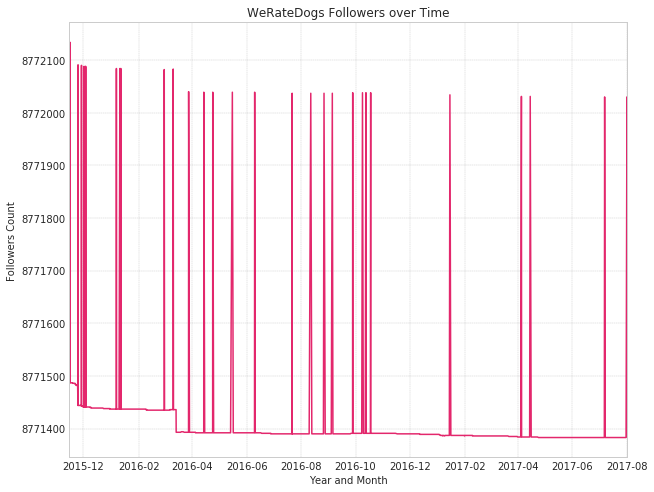

```python
# I want to see how followers count behaves during the period in which the API was running
plt.figure(figsize=(10, 8))
plt.xlim([datetime.date(wrd.timestamp.min()), datetime.date(wrd.timestamp.max())])
plt.xlabel('Year and Month')
plt.ylabel('Followers Count')
plt.plot(wrd.timestamp, wrd.followers_count, color = '#e3276c')
plt.grid(color = 'gray', linestyle = '-.', linewidth = '.2')
plt.title('WeRateDogs Followers over Time');
plt.savefig('followers-count')
plt.show();
```

```python
# Get followers range
dpl(wrd.followers_count.min())
dpl(wrd.followers_count.max())
dpl(wrd.followers_count.max()-wrd.followers_count.min())
```

```
8771383
```

```
8772134
```

```
751
```

```python
# Sum tweets count grouped by two weeks basis
fortnightly_tweets = df.reset_index().groupby(pd.Grouper(key = 'timestamp', freq = "SM")).count().reset_index()
fortnightly_tweets = fortnightly_tweets[['timestamp', 'index']]
fortnightly_tweets['tweets'] = fortnightly_tweets['index']
fortnightly_tweets = fortnightly_tweets.drop('index', axis = 1)
fortnightly_tweets.head()
```

|  | timestamp | tweets |
| --- | --- | --- |
| 0 | 2015-11-15 | 278 |
| 1 | 2015-11-30 | 233 |
| 2 | 2015-12-15 | 136 |
| 3 | 2015-12-31 | 88 |
| 4 | 2016-01-15 | 79 |

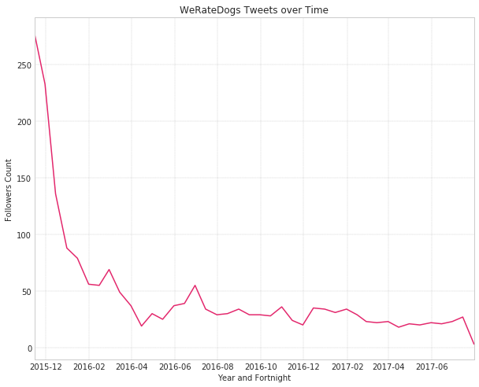

```python
# Plot tweets over time
plt.figure(figsize=(10, 8))
plt.xlim([datetime.date(fortnightly_tweets.timestamp.min()), datetime.date(fortnightly_tweets.timestamp.max())])
plt.xlabel('Year and Fortnight')
plt.ylabel('Followers Count')
plt.plot(fortnightly_tweets.timestamp, fortnightly_tweets.tweets, color = '#e3276c')
plt.grid(color = 'gray', linestyle = '-.', linewidth = '.2')
plt.title('WeRateDogs Tweets over Time');
plt.savefig('tweets-count')
plt.show();
```

> By the end of 2015, WeRateDogs tweeted over 250 rates in a couple of weeks. That number decreased considerably the following years by tweeting less than 25 rates per week in the summer of 2017.

```python
# I want to lookout for curiosities in the dogs
initial_count = df.name[df.name != 'None'].str[0].value_counts()
initial_count
```

```
B    133
C    132
S    127
L     87
M     82
R     81
T     74
D     72
J     71
A     64
K     61
P     59
G     51
O     47
W     42
H     42
F     35
E     30
N     19
Z     13
V      8
I      7
Y      3
Q      1
U      1
Name: name, dtype: int64
```

> For the tweets with dog names, the most common names for dogs start with 'B', 'C' or 'S'

```python
# Drop unknown names, get first letter and Review
initials = pd.DataFrame(df.name[df.name != 'None'].str[0]).reset_index().drop('index', axis = 1)
initials.head()
```

|  | name |
| --- | --- |
| 0 | P |
| 1 | T |
| 2 | A |
| 3 | D |
| 4 | F |

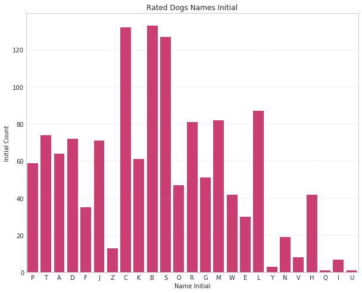

```python
# Plot dogs names initials
sns.set_style("whitegrid")
sns.axes_style("whitegrid")
fig, ax = plt.subplots(figsize = (10,8))
plt.grid(color = 'gray', linestyle = '-.', linewidth = '.2')
p = sns.countplot(data = initials, x = 'name', color = '#e3276c', ax = ax)
ax.set(xlabel='Name Initial', ylabel='Initial Count')
plt.title('Rated Dogs Names Initial')
fig = p.get_figure()
fig.savefig('initials');
```

```python
# Separate dog breed and ratings
dog_breed = df[['dog_breed','rating']]
dog_breed
```

|  | dog_breed | rating |
| --- | --- | --- |
| 892420643555336193 | None | 1.30 |
| 892177421306343426 | chihuahua | 1.30 |
| 891815181378084864 | chihuahua | 1.20 |
| 891689557279858688 | labrador retriever | 1.30 |
| 891327558926688256 | basset | 1.20 |
| 891087950875897856 | chesapeake bay retriever | 1.30 |
| 890971913173991426 | appenzeller | 1.30 |
| 890729181411237888 | pomeranian | 1.30 |
| 890609185150312448 | irish terrier | 1.30 |
| 890240255349198849 | pembroke | 1.40 |
| 890006608113172480 | samoyed | 1.30 |
| 889880896479866881 | french bulldog | 1.30 |
| 889665388333682689 | pembroke | 1.30 |
| 889638837579907072 | french bulldog | 1.20 |
| 889531135344209921 | golden retriever | 1.30 |
| 889278841981685760 | whippet | 1.30 |
| 888917238123831296 | golden retriever | 1.20 |
| 888804989199671297 | golden retriever | 1.30 |
| 888554962724278272 | siberian husky | 1.30 |
| 888078434458587136 | french bulldog | 1.20 |
| 887705289381826560 | basset | 1.30 |
| 887517139158093824 | None | 1.40 |
| 887473957103951883 | pembroke | 1.30 |
| 887343217045368832 | mexican hairless | 1.30 |
| 887101392804085760 | samoyed | 1.20 |
| 886983233522544640 | chihuahua | 1.30 |
| 886736880519319552 | kuvasz | 1.30 |
| 886680336477933568 | None | 1.30 |
| 886366144734445568 | french bulldog | 1.20 |
| 886258384151887873 | pug | 1.30 |
| ... | ... | ... |
| 666411507551481857 | None | 0.20 |
| 666407126856765440 | black-and-tan coonhound | 0.70 |
| 666396247373291520 | chihuahua | 0.90 |
| 666373753744588802 | soft-coated wheaten terrier | 1.10 |
| 666362758909284353 | None | 0.60 |
| 666353288456101888 | malamute | 0.80 |
| 666345417576210432 | golden retriever | 1.00 |
| 666337882303524864 | newfoundland | 0.90 |
| 666293911632134144 | None | 0.30 |
| 666287406224695296 | maltese dog | 0.50 |
| 666273097616637952 | italian greyhound | 1.10 |
| 666268910803644416 | None | 1.00 |
| 666104133288665088 | None | 0.10 |
| 666102155909144576 | english setter | 1.10 |
| 666099513787052032 | lhasa | 0.80 |
| 666094000022159362 | bloodhound | 0.90 |
| 666082916733198337 | pug | 0.60 |
| 666073100786774016 | walker hound | 1.00 |
| 666071193221509120 | gordon setter | 0.90 |
| 666063827256086533 | golden retriever | 1.00 |
| 666058600524156928 | miniature poodle | 0.80 |
| 666057090499244032 | golden retriever | 0.90 |
| 666055525042405380 | chow | 1.00 |
| 666051853826850816 | None | 0.20 |
| 666050758794694657 | bernese mountain dog | 1.00 |
| 666049248165822465 | miniature pinscher | 0.50 |
| 666044226329800704 | rhodesian ridgeback | 0.60 |
| 666033412701032449 | german shepherd | 0.90 |
| 666029285002620928 | redbone | 0.70 |
| 666020888022790149 | welsh springer spaniel | 0.80 |

1964 rows × 2 columns

```python
# Sort breeds by rating
dog_breed = dog_breed.sort_values(['rating'], ascending = False)
dog_breed
```

|  | dog_breed | rating |
| --- | --- | --- |
| 749981277374128128 | None | 177.60 |
| 670842764863651840 | None | 42.00 |
| 810984652412424192 | golden retriever | 3.43 |
| 860184849394610176 | None | 1.40 |
| 813812741911748608 | french bulldog | 1.40 |
| 854120357044912130 | black-and-tan coonhound | 1.40 |
| 864873206498414592 | None | 1.40 |
| 884441805382717440 | pembroke | 1.40 |
| 856282028240666624 | chihuahua | 1.40 |
| 755206590534418437 | None | 1.40 |
| 828381636999917570 | bedlington terrier | 1.40 |
| 828650029636317184 | golden retriever | 1.40 |
| 774314403806253056 | eskimo dog | 1.40 |
| 887517139158093824 | None | 1.40 |
| 742465774154047488 | None | 1.40 |
| 881536004380872706 | samoyed | 1.40 |
| 807621403335917568 | golden retriever | 1.40 |
| 832273440279240704 | pembroke | 1.40 |
| 831911600680497154 | bloodhound | 1.40 |
| 878057613040115712 | french bulldog | 1.40 |
| 778408200802557953 | pembroke | 1.40 |
| 822462944365645825 | pomeranian | 1.40 |
| 821407182352777218 | irish setter | 1.40 |
| 794205286408003585 | None | 1.40 |
| 825535076884762624 | rottweiler | 1.40 |
| 820314633777061888 | gordon setter | 1.40 |
| 851464819735769094 | None | 1.40 |
| 841439858740625411 | labrador retriever | 1.40 |
| 685547936038666240 | None | 1.40 |
| 852226086759018497 | None | 1.40 |
| ... | ... | ... |
| 666293911632134144 | None | 0.30 |
| 673700254269775872 | None | 0.30 |
| 673906403526995968 | soft-coated wheaten terrier | 0.30 |
| 699088579889332224 | None | 0.30 |
| 777885040357281792 | afghan hound | 0.30 |
| 666837028449972224 | None | 0.30 |
| 693590843962331137 | None | 0.30 |
| 676098748976615425 | None | 0.30 |
| 668643542311546881 | None | 0.30 |
| 667937095915278337 | None | 0.30 |
| 674045139690631169 | None | 0.30 |
| 674690135443775488 | None | 0.30 |
| 686003207160610816 | None | 0.30 |
| 668989615043424256 | pug | 0.30 |
| 681302363064414209 | None | 0.30 |
| 674265582246694913 | None | 0.20 |
| 668142349051129856 | None | 0.20 |
| 670826280409919488 | None | 0.20 |
| 678424312106393600 | maltese dog | 0.20 |
| 666411507551481857 | None | 0.20 |
| 666051853826850816 | None | 0.20 |
| 666786068205871104 | None | 0.20 |
| 667878741721415682 | miniature pinscher | 0.20 |
| 722974582966214656 | great dane | 0.20 |
| 678675843183484930 | None | 0.20 |
| 666104133288665088 | None | 0.10 |
| 667549055577362432 | None | 0.10 |
| 675153376133427200 | None | 0.10 |
| 670783437142401025 | None | 0.10 |
| 835152434251116546 | american staffordshire terrier | 0.00 |

1964 rows × 2 columns

```python
# Best rated dog! Image recognition cannot do its job because this dog is fully dressed! I think it is a golden retriever
# How could not be?
import urllib.request
top1name = df.name[749981277374128128]
top1tweet = df.text[749981277374128128]
dpl(top1name)
dpl(img(url = df.jpg_url.at[749981277374128128]))
dpl(top1tweet)
urllib.request.urlretrieve(df.jpg_url.at[749981277374128128], top1name+'-top1-dog.png');
```

```
'Atticus'
```

[figure not shown]

```
"This is Atticus. He's quite simply America af. 1776/10 https://t.co/GRXwMxLBkh"
```

```python
# Second best rated tweet
top2name = df.name[670842764863651840]
top2tweet = df.text[670842764863651840]
dpl(top2name)
dpl(img(url = df.jpg_url.at[670842764863651840])) # Haha, Snoop 'Dog'g is our second best dog
dpl(top2tweet)
urllib.request.urlretrieve(df.jpg_url.at[670842764863651840], top2name+'-top2-dog.png')
```

```
'None'
```

[figure not shown]

```
'After so many requests... here you go.\n\nGood dogg. 420/10 https://t.co/yfAAo1gdeY'
```

```
('None-top2-dog.png', <http.client.HTTPMessage at 0x7f0019182a90>)
```

```python
# Third best rated dog
top3name = df.name[810984652412424192]
top3tweet = df.text[810984652412424192]
dpl(top3name)
dpl(img(url = df.jpg_url.at[810984652412424192])) # Best rated dog for our known breeds lists! Definately the golden!
dpl(top3tweet)
urllib.request.urlretrieve(df.jpg_url.at[810984652412424192], top3name+'-top3-dog.png')
```

```
'Sam'
```

[figure not shown]

```
'Meet Sam. She smiles 24/7 &amp; secretly aspires to be a reindeer. \nKeep Sam smiling by clicking and sharing this link:\nhttps://t.co/98tB8y7y7t https://t.co/LouL5vdvxx'
```

```
('Sam-top3-dog.png', <http.client.HTTPMessage at 0x7f00181c2fd0>)
```

```python
# Get data to create dog breed chart
dog_breed_chart = df.copy()
dog_breed_chart.dog_breed = dog_breed_chart.dog_breed.astype(str)
dog_breed_chart
```

|  | timestamp | text | expanded_urls | name | jpg_url | img_num | favorite_count | lang | retweet_count | dog_stage | rating | dog_breed |
| --- | --- | --- | --- | --- | --- | --- | --- | --- | --- | --- | --- | --- |
| 892420643555336193 | 2017-08-01 16:23:56 | This is Phineas. He's a mystical boy. Only eve... | https://twitter.com/dog_rates/status/892420643... | Phineas | https://pbs.twimg.com/media/DGKD1-bXoAAIAUK.jpg | 1 | 36309 | en | 7729 | NaN | 1.30 | None |
| 892177421306343426 | 2017-08-01 00:17:27 | This is Tilly. She's just checking pup on you.... | https://twitter.com/dog_rates/status/892177421... | Tilly | https://pbs.twimg.com/media/DGGmoV4XsAAUL6n.jpg | 1 | 31298 | en | 5720 | NaN | 1.30 | chihuahua |
| 891815181378084864 | 2017-07-31 00:18:03 | This is Archie. He is a rare Norwegian Pouncin... | https://twitter.com/dog_rates/status/891815181... | Archie | https://pbs.twimg.com/media/DGBdLU1WsAANxJ9.jpg | 1 | 23578 | en | 3786 | NaN | 1.20 | chihuahua |
| 891689557279858688 | 2017-07-30 15:58:51 | This is Darla. She commenced a snooze mid meal... | https://twitter.com/dog_rates/status/891689557... | Darla | https://pbs.twimg.com/media/DF_q7IAWsAEuuN8.jpg | 1 | 39618 | en | 7890 | NaN | 1.30 | labrador retriever |
| 891327558926688256 | 2017-07-29 16:00:24 | This is Franklin. He would like you to stop ca... | https://twitter.com/dog_rates/status/891327558... | Franklin | https://pbs.twimg.com/media/DF6hr6BUMAAzZgT.jpg | 2 | 37819 | en | 8508 | NaN | 1.20 | basset |
| 891087950875897856 | 2017-07-29 00:08:17 | Here we have a majestic great white breaching ... | https://twitter.com/dog_rates/status/891087950... | None | https://pbs.twimg.com/media/DF3HwyEWsAABqE6.jpg | 1 | 19050 | en | 2851 | NaN | 1.30 | chesapeake bay retriever |
| 890971913173991426 | 2017-07-28 16:27:12 | Meet Jax. He enjoys ice cream so much he gets ... | https://gofundme.com/ydvmve-surgery-for-jax,ht... | Jax | https://pbs.twimg.com/media/DF1eOmZXUAALUcq.jpg | 1 | 11092 | en | 1854 | NaN | 1.30 | appenzeller |
| 890729181411237888 | 2017-07-28 00:22:40 | When you watch your owner call another dog a g... | https://twitter.com/dog_rates/status/890729181... | None | https://pbs.twimg.com/media/DFyBahAVwAAhUTd.jpg | 2 | 61187 | en | 17248 | NaN | 1.30 | pomeranian |
| 890609185150312448 | 2017-07-27 16:25:51 | This is Zoey. She doesn't want to be one of th... | https://twitter.com/dog_rates/status/890609185... | Zoey | https://pbs.twimg.com/media/DFwUU__XcAEpyXI.jpg | 1 | 26212 | en | 3925 | NaN | 1.30 | irish terrier |
| 890240255349198849 | 2017-07-26 15:59:51 | This is Cassie. She is a college pup. Studying... | https://twitter.com/dog_rates/status/890240255... | Cassie | https://pbs.twimg.com/media/DFrEyVuW0AAO3t9.jpg | 1 | 29964 | en | 6717 | doggo | 1.40 | pembroke |
| 890006608113172480 | 2017-07-26 00:31:25 | This is Koda. He is a South Australian decksha... | https://twitter.com/dog_rates/status/890006608... | Koda | https://pbs.twimg.com/media/DFnwSY4WAAAMliS.jpg | 1 | 28843 | en | 6709 | NaN | 1.30 | samoyed |
| 889880896479866881 | 2017-07-25 16:11:53 | This is Bruno. He is a service shark. Only get... | https://twitter.com/dog_rates/status/889880896... | Bruno | https://pbs.twimg.com/media/DFl99B1WsAITKsg.jpg | 1 | 26221 | en | 4565 | NaN | 1.30 | french bulldog |
| 889665388333682689 | 2017-07-25 01:55:32 | Here's a puppo that seems to be on the fence a... | https://twitter.com/dog_rates/status/889665388... | None | https://pbs.twimg.com/media/DFi579UWsAAatzw.jpg | 1 | 45168 | en | 9157 | puppo | 1.30 | pembroke |
| 889638837579907072 | 2017-07-25 00:10:02 | This is Ted. He does his best. Sometimes that'... | https://twitter.com/dog_rates/status/889638837... | Ted | https://pbs.twimg.com/media/DFihzFfXsAYGDPR.jpg | 1 | 25427 | en | 4108 | NaN | 1.20 | french bulldog |
| 889531135344209921 | 2017-07-24 17:02:04 | This is Stuart. He's sporting his favorite fan... | https://twitter.com/dog_rates/status/889531135... | Stuart | https://pbs.twimg.com/media/DFg_2PVW0AEHN3p.jpg | 1 | 14215 | en | 2060 | puppo | 1.30 | golden retriever |
| 889278841981685760 | 2017-07-24 00:19:32 | This is Oliver. You're witnessing one of his m... | https://twitter.com/dog_rates/status/889278841... | Oliver | https://pbs.twimg.com/ext_tw_video_thumb/88927... | 1 | 23687 | en | 4876 | NaN | 1.30 | whippet |
| 888917238123831296 | 2017-07-23 00:22:39 | This is Jim. He found a fren. Taught him how t... | https://twitter.com/dog_rates/status/888917238... | Jim | https://pbs.twimg.com/media/DFYRgsOUQAARGhO.jpg | 1 | 27373 | en | 4117 | NaN | 1.20 | golden retriever |
| 888804989199671297 | 2017-07-22 16:56:37 | This is Zeke. He has a new stick. Very proud o... | https://twitter.com/dog_rates/status/888804989... | Zeke | https://pbs.twimg.com/media/DFWra-3VYAA2piG.jpg | 1 | 24061 | en | 3881 | NaN | 1.30 | golden retriever |
| 888554962724278272 | 2017-07-22 00:23:06 | This is Ralphus. He's powering up. Attempting ... | https://twitter.com/dog_rates/status/888554962... | Ralphus | https://pbs.twimg.com/media/DFTH_O-UQAACu20.jpg | 3 | 18572 | en | 3186 | NaN | 1.30 | siberian husky |
| 888078434458587136 | 2017-07-20 16:49:33 | This is Gerald. He was just told he didn't get... | https://twitter.com/dog_rates/status/888078434... | Gerald | https://pbs.twimg.com/media/DFMWn56WsAAkA7B.jpg | 1 | 20482 | en | 3168 | NaN | 1.20 | french bulldog |
| 887705289381826560 | 2017-07-19 16:06:48 | This is Jeffrey. He has a monopoly on the pool... | https://twitter.com/dog_rates/status/887705289... | Jeffrey | https://pbs.twimg.com/media/DFHDQBbXgAEqY7t.jpg | 1 | 28444 | en | 4922 | NaN | 1.30 | basset |
| 887517139158093824 | 2017-07-19 03:39:09 | I've yet to rate a Venezuelan Hover Wiener. Th... | https://twitter.com/dog_rates/status/887517139... | None | https://pbs.twimg.com/ext_tw_video_thumb/88751... | 1 | 43624 | en | 10776 | NaN | 1.40 | None |
| 887473957103951883 | 2017-07-19 00:47:34 | This is Canela. She attempted some fancy porch... | https://twitter.com/dog_rates/status/887473957... | Canela | https://pbs.twimg.com/media/DFDw2tyUQAAAFke.jpg | 2 | 64672 | en | 16468 | NaN | 1.30 | pembroke |
| 887343217045368832 | 2017-07-18 16:08:03 | You may not have known you needed to see this ... | https://twitter.com/dog_rates/status/887343217... | None | https://pbs.twimg.com/ext_tw_video_thumb/88734... | 1 | 31650 | en | 9573 | NaN | 1.30 | mexican hairless |
| 887101392804085760 | 2017-07-18 00:07:08 | This... is a Jubilant Antarctic House Bear. We... | https://twitter.com/dog_rates/status/887101392... | None | https://pbs.twimg.com/media/DE-eAq6UwAA-jaE.jpg | 1 | 28791 | en | 5452 | NaN | 1.20 | samoyed |
| 886983233522544640 | 2017-07-17 16:17:36 | This is Maya. She's very shy. Rarely leaves he... | https://twitter.com/dog_rates/status/886983233... | Maya | https://pbs.twimg.com/media/DE8yicJW0AAAvBJ.jpg | 2 | 32870 | en | 7016 | NaN | 1.30 | chihuahua |
| 886736880519319552 | 2017-07-16 23:58:41 | This is Mingus. He's a wonderful father to his... | https://www.gofundme.com/mingusneedsus,https:/... | Mingus | https://pbs.twimg.com/media/DE5Se8FXcAAJFx4.jpg | 1 | 11275 | en | 2939 | NaN | 1.30 | kuvasz |
| 886680336477933568 | 2017-07-16 20:14:00 | This is Derek. He's late for a dog meeting. 13... | https://twitter.com/dog_rates/status/886680336... | Derek | https://pbs.twimg.com/media/DE4fEDzWAAAyHMM.jpg | 1 | 21131 | en | 4087 | NaN | 1.30 | None |
| 886366144734445568 | 2017-07-15 23:25:31 | This is Roscoe. Another pupper fallen victim t... | https://twitter.com/dog_rates/status/886366144... | Roscoe | https://pbs.twimg.com/media/DE0BTnQUwAApKEH.jpg | 1 | 19892 | en | 2897 | pupper | 1.20 | french bulldog |
| 886258384151887873 | 2017-07-15 16:17:19 | This is Waffles. His doggles are pupside down.... | https://twitter.com/dog_rates/status/886258384... | Waffles | https://pbs.twimg.com/media/DEyfTG4UMAE4aE9.jpg | 1 | 26338 | en | 5776 | NaN | 1.30 | pug |
| ... | ... | ... | ... | ... | ... | ... | ... | ... | ... | ... | ... | ... |
| 666411507551481857 | 2015-11-17 00:24:19 | This is quite the dog. Gets really excited whe... | https://twitter.com/dog_rates/status/666411507... | None | https://pbs.twimg.com/media/CT-RugiWIAELEaq.jpg | 1 | 411 | en | 301 | NaN | 0.20 | None |
| 666407126856765440 | 2015-11-17 00:06:54 | This is a southern Vesuvius bumblegruff. Can d... | https://twitter.com/dog_rates/status/666407126... | None | https://pbs.twimg.com/media/CT-NvwmW4AAugGZ.jpg | 1 | 100 | en | 32 | NaN | 0.70 | black-and-tan coonhound |
| 666396247373291520 | 2015-11-16 23:23:41 | Oh goodness. A super rare northeast Qdoba kang... | https://twitter.com/dog_rates/status/666396247... | None | https://pbs.twimg.com/media/CT-D2ZHWIAA3gK1.jpg | 1 | 159 | en | 76 | NaN | 0.90 | chihuahua |
| 666373753744588802 | 2015-11-16 21:54:18 | Those are sunglasses and a jean jacket. 11/10 ... | https://twitter.com/dog_rates/status/666373753... | None | https://pbs.twimg.com/media/CT9vZEYWUAAlZ05.jpg | 1 | 174 | en | 85 | NaN | 1.10 | soft-coated wheaten terrier |
| 666362758909284353 | 2015-11-16 21:10:36 | Unique dog here. Very small. Lives in containe... | https://twitter.com/dog_rates/status/666362758... | None | https://pbs.twimg.com/media/CT9lXGsUcAAyUFt.jpg | 1 | 727 | en | 521 | NaN | 0.60 | None |
| 666353288456101888 | 2015-11-16 20:32:58 | Here we have a mixed Asiago from the Galápagos... | https://twitter.com/dog_rates/status/666353288... | None | https://pbs.twimg.com/media/CT9cx0tUEAAhNN_.jpg | 1 | 199 | en | 66 | NaN | 0.80 | malamute |
| 666345417576210432 | 2015-11-16 20:01:42 | Look at this jokester thinking seat belt laws ... | https://twitter.com/dog_rates/status/666345417... | None | https://pbs.twimg.com/media/CT9Vn7PWoAA_ZCM.jpg | 1 | 274 | en | 128 | NaN | 1.00 | golden retriever |
| 666337882303524864 | 2015-11-16 19:31:45 | This is an extremely rare horned Parthenon. No... | https://twitter.com/dog_rates/status/666337882... | None | https://pbs.twimg.com/media/CT9OwFIWEAMuRje.jpg | 1 | 182 | en | 84 | NaN | 0.90 | newfoundland |
| 666293911632134144 | 2015-11-16 16:37:02 | This is a funny dog. Weird toes. Won't come do... | https://twitter.com/dog_rates/status/666293911... | None | https://pbs.twimg.com/media/CT8mx7KW4AEQu8N.jpg | 1 | 469 | en | 321 | NaN | 0.30 | None |
| 666287406224695296 | 2015-11-16 16:11:11 | This is an Albanian 3 1/2 legged Episcopalian... | https://twitter.com/dog_rates/status/666287406... | None | https://pbs.twimg.com/media/CT8g3BpUEAAuFjg.jpg | 1 | 138 | en | 62 | NaN | 0.50 | maltese dog |
| 666273097616637952 | 2015-11-16 15:14:19 | Can take selfies 11/10 https://t.co/ws2AMaNwPW | https://twitter.com/dog_rates/status/666273097... | None | https://pbs.twimg.com/media/CT8T1mtUwAA3aqm.jpg | 1 | 161 | en | 73 | NaN | 1.10 | italian greyhound |
| 666268910803644416 | 2015-11-16 14:57:41 | Very concerned about fellow dog trapped in com... | https://twitter.com/dog_rates/status/666268910... | None | https://pbs.twimg.com/media/CT8QCd1WEAADXws.jpg | 1 | 96 | en | 32 | NaN | 1.00 | None |
| 666104133288665088 | 2015-11-16 04:02:55 | Not familiar with this breed. No tail (weird).... | https://twitter.com/dog_rates/status/666104133... | None | https://pbs.twimg.com/media/CT56LSZWoAAlJj2.jpg | 1 | 13697 | en | 6004 | NaN | 0.10 | None |
| 666102155909144576 | 2015-11-16 03:55:04 | Oh my. Here you are seeing an Adobe Setter giv... | https://twitter.com/dog_rates/status/666102155... | None | https://pbs.twimg.com/media/CT54YGiWUAEZnoK.jpg | 1 | 72 | en | 11 | NaN | 1.10 | english setter |
| 666099513787052032 | 2015-11-16 03:44:34 | Can stand on stump for what seems like a while... | https://twitter.com/dog_rates/status/666099513... | None | https://pbs.twimg.com/media/CT51-JJUEAA6hV8.jpg | 1 | 143 | en | 60 | NaN | 0.80 | lhasa |
| 666094000022159362 | 2015-11-16 03:22:39 | This appears to be a Mongolian Presbyterian mi... | https://twitter.com/dog_rates/status/666094000... | None | https://pbs.twimg.com/media/CT5w9gUW4AAsBNN.jpg | 1 | 154 | en | 67 | NaN | 0.90 | bloodhound |
| 666082916733198337 | 2015-11-16 02:38:37 | Here we have a well-established sunblockerspan... | https://twitter.com/dog_rates/status/666082916... | None | https://pbs.twimg.com/media/CT5m4VGWEAAtKc8.jpg | 1 | 103 | en | 41 | NaN | 0.60 | pug |
| 666073100786774016 | 2015-11-16 01:59:36 | Let's hope this flight isn't Malaysian (lol). ... | https://twitter.com/dog_rates/status/666073100... | None | https://pbs.twimg.com/media/CT5d9DZXAAALcwe.jpg | 1 | 297 | en | 147 | NaN | 1.00 | walker hound |
| 666071193221509120 | 2015-11-16 01:52:02 | Here we have a northern speckled Rhododendron.... | https://twitter.com/dog_rates/status/666071193... | None | https://pbs.twimg.com/media/CT5cN_3WEAAlOoZ.jpg | 1 | 136 | en | 53 | NaN | 0.90 | gordon setter |
| 666063827256086533 | 2015-11-16 01:22:45 | This is the happiest dog you will ever see. Ve... | https://twitter.com/dog_rates/status/666063827... | None | https://pbs.twimg.com/media/CT5Vg_wXIAAXfnj.jpg | 1 | 445 | en | 198 | NaN | 1.00 | golden retriever |
| 666058600524156928 | 2015-11-16 01:01:59 | Here is the Rand Paul of retrievers folks! He'... | https://twitter.com/dog_rates/status/666058600... | None | https://pbs.twimg.com/media/CT5Qw94XAAA_2dP.jpg | 1 | 105 | en | 54 | NaN | 0.80 | miniature poodle |
| 666057090499244032 | 2015-11-16 00:55:59 | My oh my. This is a rare blond Canadian terrie... | https://twitter.com/dog_rates/status/666057090... | None | https://pbs.twimg.com/media/CT5PY90WoAAQGLo.jpg | 1 | 270 | en | 127 | NaN | 0.90 | golden retriever |
| 666055525042405380 | 2015-11-16 00:49:46 | Here is a Siberian heavily armored polar bear ... | https://twitter.com/dog_rates/status/666055525... | None | https://pbs.twimg.com/media/CT5N9tpXIAAifs1.jpg | 1 | 410 | en | 221 | NaN | 1.00 | chow |
| 666051853826850816 | 2015-11-16 00:35:11 | This is an odd dog. Hard on the outside but lo... | https://twitter.com/dog_rates/status/666051853... | None | https://pbs.twimg.com/media/CT5KoJ1WoAAJash.jpg | 1 | 1128 | en | 778 | NaN | 0.20 | None |
| 666050758794694657 | 2015-11-16 00:30:50 | This is a truly beautiful English Wilson Staff... | https://twitter.com/dog_rates/status/666050758... | None | https://pbs.twimg.com/media/CT5Jof1WUAEuVxN.jpg | 1 | 124 | en | 51 | NaN | 1.00 | bernese mountain dog |
| 666049248165822465 | 2015-11-16 00:24:50 | Here we have a 1949 1st generation vulpix. Enj... | https://twitter.com/dog_rates/status/666049248... | None | https://pbs.twimg.com/media/CT5IQmsXIAAKY4A.jpg | 1 | 96 | en | 40 | NaN | 0.50 | miniature pinscher |
| 666044226329800704 | 2015-11-16 00:04:52 | This is a purebred Piers Morgan. Loves to Netf... | https://twitter.com/dog_rates/status/666044226... | None | https://pbs.twimg.com/media/CT5Dr8HUEAA-lEu.jpg | 1 | 272 | en | 132 | NaN | 0.60 | rhodesian ridgeback |
| 666033412701032449 | 2015-11-15 23:21:54 | Here is a very happy pup. Big fan of well-main... | https://twitter.com/dog_rates/status/666033412... | None | https://pbs.twimg.com/media/CT4521TWwAEvMyu.jpg | 1 | 112 | en | 41 | NaN | 0.90 | german shepherd |
| 666029285002620928 | 2015-11-15 23:05:30 | This is a western brown Mitsubishi terrier. Up... | https://twitter.com/dog_rates/status/666029285... | None | https://pbs.twimg.com/media/CT42GRgUYAA5iDo.jpg | 1 | 121 | en | 42 | NaN | 0.70 | redbone |
| 666020888022790149 | 2015-11-15 22:32:08 | Here we have a Japanese Irish Setter. Lost eye... | https://twitter.com/dog_rates/status/666020888... | None | https://pbs.twimg.com/media/CT4udn0WwAA0aMy.jpg | 1 | 2422 | en | 463 | NaN | 0.80 | welsh springer spaniel |

1964 rows × 12 columns

```python
# Get data to create dog breed chart (cont.)
dog_breed_chart = df.copy()
dog_breed_chart.dog_breed = dog_breed_chart.dog_breed.astype(str)
dog_breed_chart = dog_breed_chart.dog_breed.value_counts().rename_axis('breed').to_frame('counts')
dog_breed_chart = dog_breed_chart.reset_index()
dog_breed_chart.breed[11:] = 'Other'
dog_breed_chart.breed = dog_breed_chart.breed.str.title() # Title case the names for the chart labels
dog_breed_chart = dog_breed_chart.groupby(['breed'])['counts'].sum().to_frame()
dog_breed_chart
```

| breed | counts |
| --- | --- |
| Chihuahua | 90 |
| Chow | 48 |
| Golden Retriever | 156 |
| Labrador Retriever | 104 |
| Malamute | 33 |
| None | 305 |
| Other | 941 |
| Pembroke | 94 |
| Pomeranian | 41 |
| Pug | 62 |
| Samoyed | 41 |
| Toy Poodle | 49 |

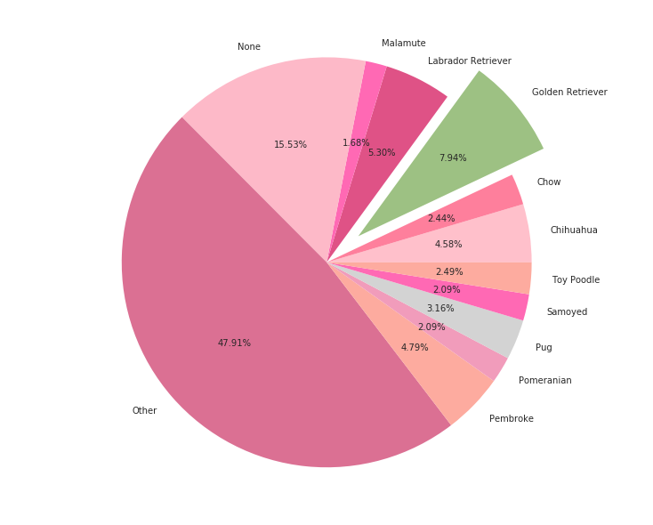

```python
# Chart breed of rated dogs
fig2 = plt.figure(figsize=(10, 8))
colors = ['pink', '#FE7F9C', '#9dc183','#DF5286','hotpink','#fdb9c8','palevioletred', '#FDAB9F', '#F19CBB', 'lightgray','hotpink', '#FDAB9F']
explode = (0,0,0.2,0,0,0,0,0,0,0,0,0)
ax = fig2.add_axes([0,0,1,1])
ax.axis('equal')
ax.pie(dog_breed_chart.counts, explode=explode, labels = dog_breed_chart.index ,autopct='%1.2f%%', colors = colors)
plt.savefig('breeds')
plt.show();
```

> There are 15.53 % of tweets whose breed are unknown. And the outstanding recurrent breed is the Golden Retriever.

```python
# Get data for best rated by dog stage
dogstage = df[['dog_stage','dog_breed','rating']]
dogstage.dog_stage.fillna('unknown', inplace = True)
dogstage.sort_values('rating', ascending = False, inplace = True)
dogstage.reset_index(inplace = True)
dogstage = dogstage[dogstage.dog_stage != 'unknown']
dogstage = pd.pivot_table(dogstage, values='rating', index=['dog_stage','dog_breed'])
dogstage
```

| dog_stage | dog_breed | rating |
| --- | --- | --- |
| doggo | None | 1.13 |
|  | basset | 1.05 |
|  | beagle | 1.10 |
|  | bedlington terrier | 1.10 |
|  | blenheim spaniel | 1.10 |
|  | border collie | 1.30 |
|  | boston bull | 1.10 |
|  | boxer | 1.30 |
|  | briard | 1.20 |
|  | chesapeake bay retriever | 1.30 |
|  | chihuahua | 1.15 |
|  | cocker spaniel | 1.15 |
|  | curly-coated retriever | 1.30 |
|  | dalmatian | 0.85 |
|  | dandie dinmont | 1.30 |
|  | english springer | 1.10 |
|  | eskimo dog | 1.30 |
|  | german shepherd | 1.13 |
|  | german short-haired pointer | 1.10 |
|  | golden retriever | 1.21 |
|  | great dane | 1.10 |
|  | great pyrenees | 1.30 |
|  | irish setter | 1.40 |
|  | komondor | 1.20 |
|  | labrador retriever | 1.22 |
|  | norwegian elkhound | 1.10 |
|  | old english sheepdog | 1.20 |
|  | pembroke | 1.40 |
|  | pomeranian | 1.15 |
|  | schipperke | 1.20 |
| ... | ... | ... |
| pupper | shetland sheepdog | 1.10 |
|  | shih-tzu | 1.05 |
|  | siberian husky | 1.15 |
|  | soft-coated wheaten terrier | 0.90 |
|  | staffordshire bullterrier | 1.00 |
|  | tibetan mastiff | 1.30 |
|  | toy poodle | 1.07 |
|  | vizsla | 1.20 |
|  | walker hound | 0.90 |
|  | whippet | 0.90 |
|  | yorkshire terrier | 0.90 |
| puppo | None | 1.30 |
|  | airedale | 1.00 |
|  | american staffordshire terrier | 1.30 |
|  | bernese mountain dog | 1.30 |
|  | cardigan | 1.30 |
|  | chow | 1.10 |
|  | eskimo dog | 1.20 |
|  | flat-coated retriever | 1.25 |
|  | german shepherd | 1.30 |
|  | golden retriever | 1.28 |
|  | labrador retriever | 1.10 |
|  | lakeland terrier | 1.30 |
|  | malamute | 1.00 |
|  | miniature pinscher | 1.20 |
|  | old english sheepdog | 0.90 |
|  | pembroke | 1.30 |
|  | rottweiler | 1.40 |
|  | shetland sheepdog | 1.30 |
|  | siberian husky | 1.20 |

126 rows × 1 columns

```python
# Get dog stage names
d = list(set(dogstage.index.get_level_values(0)))
d
```

```
['floofer', 'doggo', 'pupper', 'puppo']
```

```python
# Get the top rated breeds for each dog stage
for x in d:
    print(x.title())
    c = dogstage['rating'][x].to_frame()
    c = c.sort_values('rating', ascending = False)
    dpl(c.head(3))
    print('---------------------------\n')
```

```
Floofer
```

| dog_breed | rating |
| --- | --- |
| chow | 1.30 |
| samoyed | 1.30 |
| golden retriever | 1.20 |

```
---------------------------

Doggo
```

| dog_breed | rating |
| --- | --- |
| irish setter | 1.40 |
| pembroke | 1.40 |
| chesapeake bay retriever | 1.30 |

```
---------------------------

Pupper
```

| dog_breed | rating |
| --- | --- |
| black-and-tan coonhound | 1.40 |
| saluki | 1.30 |
| tibetan mastiff | 1.30 |

```
---------------------------

Puppo
```

| dog_breed | rating |
| --- | --- |
| rottweiler | 1.40 |
| None | 1.30 |
| lakeland terrier | 1.30 |

> The top rated breeds for each dog stage are the following:

| Doggo | Puppo | Floofler | Pupper |
| --- | --- | --- | --- |
| Irish Setter : 1.40 | Rottweiler : 1.40 | Chow: 1.30 | Black-and-tan Coonhound : 1.40 |
| Pembroke : 1.40 |  | Samoyed : 1.30 |  |

### Insights

Well, this has been an interesting dataset. After dealing with unreadable data, encounter myself with data within data, cleaning all of that and be able to take a deeper look onto the real information, I found out a couple of interesting things.

To begin, I decided to check the behavior of the followers of WeRateDogs while I was running the twitter API. By the starting point, the accound had the maximum followers count for the period, with 8.772.134 followers, and this number fluctuated during the following minutes by 751 points, going up and down, being the minimum 8.771.383 followers by the end of this period. The odd thing about this is how many times it went 751 points up and down in so few minutes. It was like 751 people were playing with the "follow" button te see how many spikes I would have in my chart.

Another random fact that I had fun with just thinking about it, was to find the most common initial in the rated dogs names. There are dog names with almost every letter in the alphabet, missing only I think the X. But the winners here are the B, C and S.. with over 120 dogs rated for each letter! More than 120 rated whose names began with the letter B, more than 120 rated whose names began with the letter C, and te same for S! It may not be a critical information from this data, but I found it out interesting to tell. `¯\_(ツ)_/¯`

The best for the end, of course this is a data were WeRateDogs, then I think everyone wants to know who the best rated dogs are. I would like to start the awards with the best rated dog breeds in each dog stage, which they are 'doggo', 'puppo', 'floofer' and 'pupper'. In the Doggo category we have a tie between the Irish Setter and the Pembroke, both with a rating of 1.4. For the Puppo stage, the winner is the Rottweiler with a rating of 1.4. Followed by the Black-and-ran Coonhound rated with 1.4 as a Pupper, and finally, another tie for the Floofer stage with a rating of 1.3, we have the Chow and the Samoyed.

So this are the best rated breeds? Actually, no. The issue with this data, is that not all the rates contain the dog stage information, in fact, only 16.29% of the rates included the dog stage. For that matter, the previous award is not that well deserved. Let's keep the quest to find the best rated breeds then!

There are 15.53% of rated dogs whose breeds we do not know, I do not think that this would be relevant to the result which says that the most common rated dog breed is the Golden Retriever `#WeLoveGolden`. But wait, I want to know who the best rated dogs are, and we are going to find it!

For the top 3 dogs I will go from bottom to top, for the top 3 in third place we have... Sam! "She smiles 24/7", this is a Golden Retriever.

In second place we have... ...wait what? This is Snoop Dogg, `☜(⌒▽⌒)☞` this is a "Good Dogg". I do not think there is a breed for Snoop Dogg, don't you think?

Finally, the last but not least, we have the best of the bests, the guardian of lost souls, the powerful, the pleasurable, the indestructible... Atticus! "He's quite simply America". Image recognition did not work with him because Atticus is fully dressed, but I bet he is a Golden Retriver!

### Conclusion

What is at the eyesight does not need glasses. We can definately say the best rated dogs are **Golden Retrievers**. Why? `◖ᵔᴥᵔ◗` Because "they're good dogs Brent."

Go Back to the top

```python
# Time at the end of the code to track elapsed time
elapsed = round((time.time() - notebk_time)/60, 2)
print('----- Completed in {} minutes -----'.format(elapsed))
```

```
----- Completed in 0.43 minutes -----
```

```python
#Convert notebook into html file
from subprocess import call
call(['python', '-m', 'nbconvert', 'wrangle_act.ipynb'])
```

```
0
```